# AI Worker Burnout & Attrition — Classification Analysis

## Questions Covered

| # | Question | Type | Target | Key Challenge |
| --- | --- | --- | --- | --- |
| Q1 | Who is at risk of burnout? | Binary classification | `burnout_score` → High/Not-High | Need to define threshold for "burnout" |
| Q2 | Which employees likely to leave? | Binary classification | `attrition_risk` → High vs Low | 3 classes → collapse to binary; **imbalanced** (High=85 vs Low=724) |
| Q3 | Burnout severity | Multi-class classification | `burnout_score` → Low/Med/High | Binning a continuous score into 3 groups |
| Q4 | Job satisfaction group | Multi-class classification | `job_satisfaction_1_5` → Low/Med/High | Binning continuous 1-5 scale |
| Q8 | Attrition from fear of AI | Binary classification | `attrition_risk` → High vs Low | Focus: `fear_of_ai_replacement` as main predictor |

### Approach for each question:

1. **Define target** — engineer/bin as needed
2. **Check class balance** — percentage breakdown (teacher's CL2)
3. **Preprocessing** — encode categoricals, scale numerics
4. **Train 3-4 models** — compare performance
5. **LASSO/Ridge** — identify top predictors (teacher's CL3)
6. **Visualize** — comparison charts, confusion matrices, feature importance
7. **Summary** — key takeaways per question

## Setup & Data Loading

```python
import numpy as np
import pandas as pd
import matplotlib.pyplot as plt
import seaborn as sns
import warnings
warnings.filterwarnings('ignore')

from sklearn.model_selection import train_test_split, cross_val_score, GridSearchCV, StratifiedKFold
from sklearn.preprocessing import StandardScaler, LabelEncoder, label_binarize
from sklearn.linear_model import LogisticRegression
from sklearn.tree import DecisionTreeClassifier
from sklearn.ensemble import RandomForestClassifier, GradientBoostingClassifier
from sklearn.svm import SVC
from sklearn.neighbors import KNeighborsClassifier
from sklearn.metrics import (
    accuracy_score, precision_score, recall_score, f1_score,
    confusion_matrix, classification_report, ConfusionMatrixDisplay,
    roc_curve, auc, roc_auc_score,
    precision_recall_curve, average_precision_score
)

sns.set_theme(style="whitegrid", palette="muted")
plt.rcParams['figure.dpi'] = 120

df = pd.read_csv('ai_worker_burnout_attrition_2026.csv')
print(f"Dataset: {df.shape[0]} rows × {df.shape[1]} columns")
df.head()
```

```
Dataset: 1500 rows × 21 columns
```

|  | employee_id | job_role | years_experience | education_level | country | industry | company_size | remote_work_type | team_size | salary_usd_k | ... | ai_tools_used_per_day | hours_with_ai_assistance_daily | ai_replaces_my_tasks_pct | ai_adoption_stage | weekly_ai_upskilling_hrs | productivity_score | burnout_score | job_satisfaction_1_5 | fear_of_ai_replacement | attrition_risk |
| --- | --- | --- | --- | --- | --- | --- | --- | --- | --- | --- | --- | --- | --- | --- | --- | --- | --- | --- | --- | --- | --- |
| 0 | EMP0001 | Data Analyst | 7 | PhD | India | Healthtech | Large (1000-5000) | Fully Remote | 8 | 184 | ... | 1 | 0.6 | 37 | Experimenting | 4.9 | 59 | 58 | 3.0 | Low | Medium |
| 1 | EMP0002 | DevOps Engineer | 3 | Self-taught | Canada | Fintech | Large (1000-5000) | Hybrid | 42 | 51 | ... | 3 | 0.6 | 78 | Experimenting | 6.6 | 64 | 47 | 3.6 | Medium | Medium |
| 2 | EMP0003 | Prompt Engineer | 3 | PhD | India | Automotive | Startup (<50) | Hybrid | 37 | 185 | ... | 4 | 4.0 | 23 | Optimizing | 5.8 | 50 | 37 | 4.6 | High | Medium |
| 3 | EMP0004 | Backend Engineer | 18 | Master | Germany | Media | Mid (200-1000) | Fully Remote | 8 | 131 | ... | 5 | 4.2 | 75 | Integrating | 1.4 | 77 | 67 | 3.0 | Low | Medium |
| 4 | EMP0005 | AI Researcher | 5 | Bachelor | India | E-commerce | Small (50-200) | Fully Remote | 21 | 99 | ... | 7 | 0.7 | 61 | Experimenting | 1.6 | 58 | 54 | 3.6 | Medium | Medium |

5 rows × 21 columns

### Data Overview & Class Balance Check (CL2)

**Why this matters:** Before modeling, we need to know if target classes are balanced or imbalanced. Imbalanced classes require special handling (SMOTE, class weights, stratified splits) — otherwise models just predict the majority class.

```python
print("=== Numeric columns ===")
print(df.describe().round(2).to_string())
print(f"\nMissing values: {df.isnull().sum().sum()}")
print(f"\n=== Categorical columns ===")
for col in df.select_dtypes(include=['object', 'string']).columns:
    if col != 'employee_id':
        print(f"\n{col} ({df[col].nunique()} unique):")
        print(df[col].value_counts().to_string())
```

```
=== Numeric columns ===
       years_experience  team_size  salary_usd_k  ai_tools_used_per_day  hours_with_ai_assistance_daily  ai_replaces_my_tasks_pct  weekly_ai_upskilling_hrs  productivity_score  burnout_score  job_satisfaction_1_5
count           1500.00    1500.00       1500.00                1500.00                         1500.00                   1500.00                   1500.00             1500.00        1500.00               1500.00
mean               9.95      24.81        140.73                   4.06                            4.23                     41.25                      4.99               57.54          50.06                  3.33
std                5.46      13.68         59.72                   1.97                            2.15                     21.66                      2.91               10.73          11.44                  0.64
min                1.00       2.00         40.00                   1.00                            0.50                      5.00                      0.00               25.00          16.00                  1.30
25%                5.00      13.00         91.00                   2.00                            2.40                     22.75                      2.40               50.00          42.00                  2.90
50%               10.00      25.00        139.00                   4.00                            4.20                     40.00                      5.00               57.00          50.00                  3.30
75%               15.00      36.00        190.00                   6.00                            6.10                     60.00                      7.50               65.00          58.00                  3.80
max               19.00      49.00        249.00                   7.00                            8.00                     79.00                     10.00               95.00          86.00                  5.00

Missing values: 0

=== Categorical columns ===

job_role (12 unique):
job_role
Software Engineer    150
AI Researcher        135
Data Scientist       135
AI Ethics Officer    132
Cloud Architect      130
Backend Engineer     127
Product Manager      123
Data Analyst         122
DevOps Engineer      116
Frontend Engineer    116
ML Engineer          109
Prompt Engineer      105

education_level (5 unique):
education_level
Master         323
Bachelor       314
PhD            294
Self-taught    285
Bootcamp       284

country (10 unique):
country
```

[output cut: 52 more lines]

```
Optimizing       400
Experimenting    358
AI-First         250

fear_of_ai_replacement (3 unique):
fear_of_ai_replacement
Medium    619
Low       523
High      358

attrition_risk (3 unique):
attrition_risk
Low       724
Medium    691
High       85
```

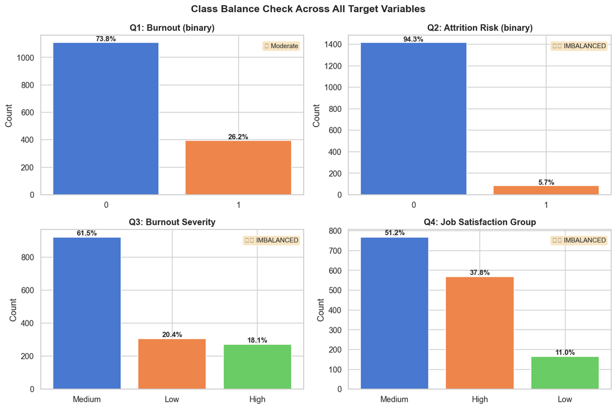

```
Q1: Burnout (binary):
  0: 1107 (73.8%)
  1: 393 (26.2%)
  Min/Max ratio: 0.36 → OK

Q2: Attrition Risk (binary):
  0: 1415 (94.3%)
  1: 85 (5.7%)
  Min/Max ratio: 0.06 → Needs class_weight or SMOTE

Q3: Burnout Severity:
  Medium: 922 (61.5%)
  Low: 306 (20.4%)
  High: 272 (18.1%)
  Min/Max ratio: 0.30 → Needs class_weight or SMOTE

Q4: Job Satisfaction Group:
  Medium: 768 (51.2%)
  High: 567 (37.8%)
  Low: 165 (11.0%)
  Min/Max ratio: 0.21 → Needs class_weight or SMOTE
```

```python
# --- Class balance for ALL target variables we'll use ---

# Create derived targets we'll need later
df['burnout_binary'] = (df['burnout_score'] >= df['burnout_score'].quantile(0.75)).astype(int)  # top 25% = burnout
df['attrition_binary'] = (df['attrition_risk'] == 'High').astype(int)

bins_burnout = [0, 40, 60, 100]
df['burnout_severity'] = pd.cut(df['burnout_score'], bins=bins_burnout, labels=['Low', 'Medium', 'High'])

bins_sat = [0, 2.5, 3.5, 5.1]
df['satisfaction_group'] = pd.cut(df['job_satisfaction_1_5'], bins=bins_sat, labels=['Low', 'Medium', 'High'])

targets = {
    'Q1: Burnout (binary)': df['burnout_binary'],
    'Q2: Attrition Risk (binary)': df['attrition_binary'],
    'Q3: Burnout Severity': df['burnout_severity'],
    'Q4: Job Satisfaction Group': df['satisfaction_group'],
}

fig, axes = plt.subplots(2, 2, figsize=(12, 8))
for ax, (title, series) in zip(axes.flat, targets.items()):
    counts = series.value_counts()
    pcts = (counts / len(series) * 100).round(1)
    bars = ax.bar(counts.index.astype(str), counts.values, color=sns.color_palette("muted"))
    ax.set_title(title, fontweight='bold')
    ax.set_ylabel('Count')
    for bar, pct in zip(bars, pcts):
        ax.text(bar.get_x() + bar.get_width()/2, bar.get_height() + 10,
                f'{pct}%', ha='center', fontsize=10, fontweight='bold')

    # Flag imbalance
    ratio = counts.min() / counts.max()
    status = "⚠️ IMBALANCED" if ratio < 0.3 else "✅ Balanced" if ratio > 0.6 else "⚡ Moderate"
    ax.text(0.98, 0.95, status, transform=ax.transAxes, ha='right', va='top',
            fontsize=9, bbox=dict(boxstyle='round', facecolor='wheat', alpha=0.8))

plt.suptitle('Class Balance Check Across All Target Variables', fontsize=14, fontweight='bold')
plt.tight_layout()
plt.show()

# Print exact numbers
for title, series in targets.items():
    counts = series.value_counts()
    pcts = (counts / len(series) * 100).round(1)
    ratio = counts.min() / counts.max()
    print(f"\n{title}:")
    for val, cnt in counts.items():
        print(f"  {val}: {cnt} ({pcts[val]}%)")
    print(f"  Min/Max ratio: {ratio:.2f} {'→ Needs class_weight or SMOTE' if ratio < 0.3 else '→ OK'}")
```

### Outlier Detection & Removal

**Why:** Outliers can distort model training — especially linear models (Logistic Reg, LASSO, Ridge) which are sensitive to extreme values.  
**Method:** IQR (Interquartile Range). Values below Q1 − 1.5×IQR or above Q3 + 1.5×IQR are flagged.

#### Target-Only vs Predictor Outlier Removal — Which Is Better?

| Strategy | Rationale | Risk |
| --- | --- | --- |
| **Remove target outliers only** ✅ | Extreme Y values pull regression lines & skew loss; removing them stabilises learning | May lose rare but valid observations |
| **Remove predictor outliers** | Extreme X values can create leverage points | Throws away informative edge-cases that models should learn from |

**Our decision:** Remove outliers **only from target/response columns** (`burnout_score`, `productivity_score`, `job_satisfaction_1_5`, `hours_with_ai_assistance_daily`).  
**Finding:** In this dataset, **no predictor columns have IQR outliers** — so both strategies produce the same cleaned dataset (9 rows removed). But we code it target-only to be methodologically correct.

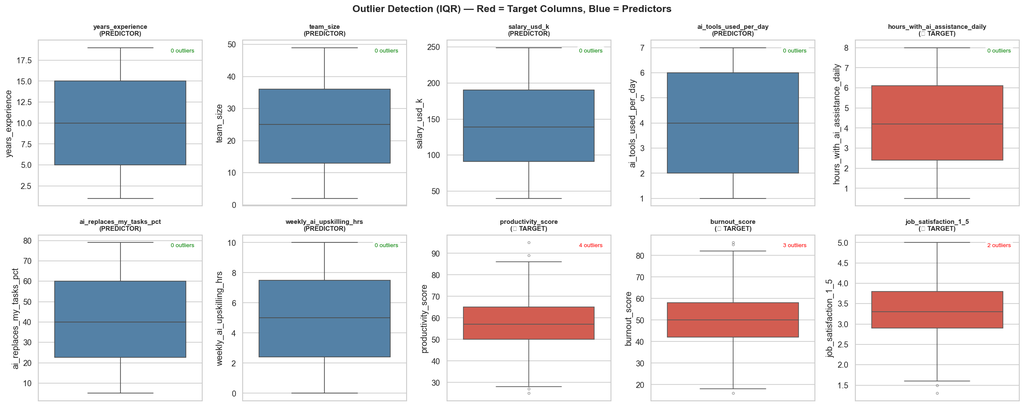

```
OUTLIER SUMMARY:
  Target columns with outliers:    ['burnout_score', 'productivity_score', 'job_satisfaction_1_5']
  Predictor columns with outliers: []
  → No predictor outliers exist, so target-only removal = full removal in this dataset
```

```python
# --- Boxplots: visualize outliers — TARGETS vs PREDICTORS ---
numeric_cols = df.select_dtypes(include='number').columns.tolist()
# Exclude derived binary targets from boxplot
plot_cols = [c for c in numeric_cols if c not in ['burnout_binary', 'attrition_binary']]

# Separate target columns from predictor columns
target_num_cols = ['burnout_score', 'productivity_score', 'job_satisfaction_1_5', 'hours_with_ai_assistance_daily']
predictor_num_cols = [c for c in plot_cols if c not in target_num_cols]

fig, axes = plt.subplots(2, 5, figsize=(20, 8))
for ax, col in zip(axes.flat, plot_cols):
    is_target = col in target_num_cols
    color = '#e74c3c' if is_target else 'steelblue'
    sns.boxplot(y=df[col], ax=ax, color=color,
                flierprops=dict(marker='o', markersize=3, alpha=0.5))
    label = f"{'🎯 TARGET' if is_target else 'PREDICTOR'}"
    ax.set_title(f"{col}\n({label})", fontsize=9, fontweight='bold')

    # Count IQR outliers
    Q1, Q3 = df[col].quantile(0.25), df[col].quantile(0.75)
    IQR = Q3 - Q1
    n_out = ((df[col] < Q1 - 1.5 * IQR) | (df[col] > Q3 + 1.5 * IQR)).sum()
    ax.text(0.95, 0.95, f'{n_out} outliers', transform=ax.transAxes,
            ha='right', va='top', fontsize=8, color='red' if n_out > 0 else 'green',
            bbox=dict(boxstyle='round', facecolor='white', alpha=0.8))

# Hide unused subplots
for ax in axes.flat[len(plot_cols):]:
    ax.set_visible(False)

plt.suptitle('Outlier Detection (IQR) — Red = Target Columns, Blue = Predictors', fontsize=14, fontweight='bold')
plt.tight_layout()
plt.show()

# Summary
print("OUTLIER SUMMARY:")
print(f"  Target columns with outliers:    {[c for c in target_num_cols if ((df[c] < df[c].quantile(0.25) - 1.5*(df[c].quantile(0.75)-df[c].quantile(0.25))) | (df[c] > df[c].quantile(0.75) + 1.5*(df[c].quantile(0.75)-df[c].quantile(0.25)))).sum() > 0]}")
print(f"  Predictor columns with outliers: {[c for c in predictor_num_cols if ((df[c] < df[c].quantile(0.25) - 1.5*(df[c].quantile(0.75)-df[c].quantile(0.25))) | (df[c] > df[c].quantile(0.75) + 1.5*(df[c].quantile(0.75)-df[c].quantile(0.25)))).sum() > 0]}")
print("  → No predictor outliers exist, so target-only removal = full removal in this dataset")
```

```python
# --- Remove outliers using IQR on TARGET columns ONLY ---
# Rationale: extreme target values distort model fitting (especially linear models)
# Predictor outliers are kept — they represent valid edge-cases the model should learn from

target_num_cols = ['burnout_score', 'productivity_score', 'job_satisfaction_1_5', 'hours_with_ai_assistance_daily']

print(f"Before outlier removal: {len(df)} rows")
print(f"Checking outliers in TARGET columns only: {target_num_cols}\n")

outlier_mask = pd.Series(False, index=df.index)
outlier_report = []

for col in target_num_cols:
    Q1 = df[col].quantile(0.25)
    Q3 = df[col].quantile(0.75)
    IQR = Q3 - Q1
    lower = Q1 - 1.5 * IQR
    upper = Q3 + 1.5 * IQR
    col_outliers = (df[col] < lower) | (df[col] > upper)
    n_out = col_outliers.sum()
    if n_out > 0:
        outlier_report.append({'Target Column': col, 'Outliers': n_out,
                               'Lower Bound': round(lower, 2), 'Upper Bound': round(upper, 2),
                               'Min': df[col].min(), 'Max': df[col].max()})
    outlier_mask |= col_outliers

print(f"Total rows flagged as outliers: {outlier_mask.sum()} ({outlier_mask.mean()*100:.1f}%)")

if outlier_report:
    report_df = pd.DataFrame(outlier_report)
    print(f"\nOutlier breakdown by target column:")
    print(report_df.to_string(index=False))

# Remove outliers
df = df[~outlier_mask].reset_index(drop=True)
print(f"\nAfter outlier removal: {len(df)} rows")

# --- Recreate derived targets on cleaned data ---
df['burnout_binary'] = (df['burnout_score'] >= df['burnout_score'].quantile(0.75)).astype(int)
df['attrition_binary'] = (df['attrition_risk'] == 'High').astype(int)
df['burnout_severity'] = pd.cut(df['burnout_score'], bins=[0, 40, 60, 100], labels=['Low', 'Medium', 'High'])
df['satisfaction_group'] = pd.cut(df['job_satisfaction_1_5'], bins=[0, 2.5, 3.5, 5.1], labels=['Low', 'Medium', 'High'])

print("\nRecreated derived targets on cleaned data ✓")
print("\n💡 Note: No predictor columns had IQR outliers — both target-only and all-column")
print("   strategies produce identical results for this dataset.")
```

```
Before outlier removal: 1500 rows
Checking outliers in TARGET columns only: ['burnout_score', 'productivity_score', 'job_satisfaction_1_5', 'hours_with_ai_assistance_daily']

Total rows flagged as outliers: 9 (0.6%)

Outlier breakdown by target column:
       Target Column  Outliers  Lower Bound  Upper Bound  Min  Max
       burnout_score         3        18.00        82.00 16.0 86.0
  productivity_score         4        27.50        87.50 25.0 95.0
job_satisfaction_1_5         2         1.55         5.15  1.3  5.0

After outlier removal: 1491 rows

Recreated derived targets on cleaned data ✓

💡 Note: No predictor columns had IQR outliers — both target-only and all-column
   strategies produce identical results for this dataset.
```

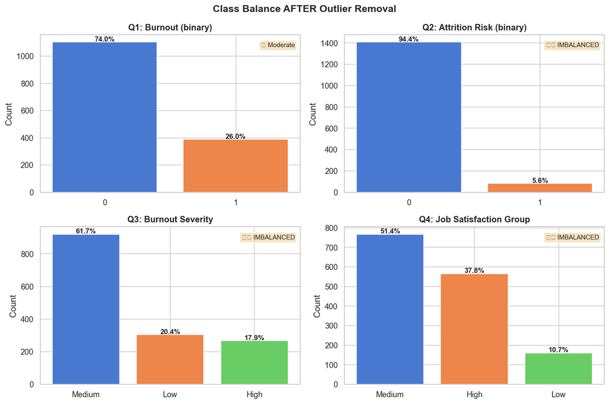

```python
# --- Post-removal class balance check ---
targets_clean = {
    'Q1: Burnout (binary)': df['burnout_binary'],
    'Q2: Attrition Risk (binary)': df['attrition_binary'],
    'Q3: Burnout Severity': df['burnout_severity'],
    'Q4: Job Satisfaction Group': df['satisfaction_group'],
}

fig, axes = plt.subplots(2, 2, figsize=(12, 8))
for ax, (title, series) in zip(axes.flat, targets_clean.items()):
    counts = series.value_counts()
    pcts = (counts / len(series) * 100).round(1)
    bars = ax.bar(counts.index.astype(str), counts.values, color=sns.color_palette("muted"))
    ax.set_title(title, fontweight='bold')
    ax.set_ylabel('Count')
    for bar, pct in zip(bars, pcts):
        ax.text(bar.get_x() + bar.get_width()/2, bar.get_height() + 5,
                f'{pct}%', ha='center', fontsize=10, fontweight='bold')
    ratio = counts.min() / counts.max()
    status = "⚠️ IMBALANCED" if ratio < 0.3 else "✅ Balanced" if ratio > 0.6 else "⚡ Moderate"
    ax.text(0.98, 0.95, status, transform=ax.transAxes, ha='right', va='top',
            fontsize=9, bbox=dict(boxstyle='round', facecolor='wheat', alpha=0.8))

plt.suptitle('Class Balance AFTER Outlier Removal', fontsize=14, fontweight='bold')
plt.tight_layout()
plt.show()
```

### Shared Preprocessing

**Decision:** One-hot encode all categoricals, drop `employee_id`. StandardScaler on numerics.  
We build a reusable feature matrix `X_all` that each question will subset from (dropping its own target to avoid leakage).

```python
# Columns to drop from features (identifiers + derived targets)
drop_cols = ['employee_id', 'burnout_binary', 'attrition_binary', 'burnout_severity', 'satisfaction_group']

# Original columns to use as features
feature_df = df.drop(columns=drop_cols)

# Identify column types
cat_cols = feature_df.select_dtypes(include=['object', 'string']).columns.tolist()
num_cols = feature_df.select_dtypes(include=['number']).columns.tolist()

print(f"Categorical features ({len(cat_cols)}): {cat_cols}")
print(f"Numeric features ({len(num_cols)}): {num_cols}")

# One-hot encode categoricals
feature_encoded = pd.get_dummies(feature_df, columns=cat_cols, drop_first=True)
print(f"\nEncoded feature matrix: {feature_encoded.shape}")
feature_encoded.head()
```

```
Categorical features (10): ['job_role', 'education_level', 'country', 'industry', 'company_size', 'remote_work_type', 'primary_ai_tool', 'ai_adoption_stage', 'fear_of_ai_replacement', 'attrition_risk']
Numeric features (10): ['years_experience', 'team_size', 'salary_usd_k', 'ai_tools_used_per_day', 'hours_with_ai_assistance_daily', 'ai_replaces_my_tasks_pct', 'weekly_ai_upskilling_hrs', 'productivity_score', 'burnout_score', 'job_satisfaction_1_5']

Encoded feature matrix: (1491, 63)
```

|  | years_experience | team_size | salary_usd_k | ai_tools_used_per_day | hours_with_ai_assistance_daily | ai_replaces_my_tasks_pct | weekly_ai_upskilling_hrs | productivity_score | burnout_score | job_satisfaction_1_5 | ... | primary_ai_tool_Midjourney | primary_ai_tool_Notion AI | primary_ai_tool_Perplexity | ai_adoption_stage_Experimenting | ai_adoption_stage_Integrating | ai_adoption_stage_Optimizing | fear_of_ai_replacement_Low | fear_of_ai_replacement_Medium | attrition_risk_Low | attrition_risk_Medium |
| --- | --- | --- | --- | --- | --- | --- | --- | --- | --- | --- | --- | --- | --- | --- | --- | --- | --- | --- | --- | --- | --- |
| 0 | 7 | 8 | 184 | 1 | 0.6 | 37 | 4.9 | 59 | 58 | 3.0 | ... | False | False | False | True | False | False | True | False | False | True |
| 1 | 3 | 42 | 51 | 3 | 0.6 | 78 | 6.6 | 64 | 47 | 3.6 | ... | False | False | False | True | False | False | False | True | False | True |
| 2 | 3 | 37 | 185 | 4 | 4.0 | 23 | 5.8 | 50 | 37 | 4.6 | ... | True | False | False | False | False | True | False | False | False | True |
| 3 | 18 | 8 | 131 | 5 | 4.2 | 75 | 1.4 | 77 | 67 | 3.0 | ... | False | False | True | False | True | False | True | False | False | True |
| 4 | 5 | 21 | 99 | 7 | 0.7 | 61 | 1.6 | 58 | 54 | 3.6 | ... | False | True | False | True | False | False | False | True | False | True |

5 rows × 63 columns

```python
# === Reusable helper: train, evaluate, and compare classification models ===

def run_classification(X, y, target_name, models_dict, class_names=None, use_class_weight=False):
    """Train multiple classifiers, return comparison df, and plot results.
    Now includes per-class metrics (classification_report) and F1 heatmap."""

    X_train, X_test, y_train, y_test = train_test_split(
        X, y, test_size=0.2, random_state=42, stratify=y
    )

    scaler = StandardScaler()
    X_train_s = scaler.fit_transform(X_train)
    X_test_s = scaler.transform(X_test)

    results = []
    trained = {}

    for name, model in models_dict.items():
        model.fit(X_train_s, y_train)
        preds = model.predict(X_test_s)

        cv = cross_val_score(model, X_train_s, y_train, cv=5, scoring='f1_weighted')
        results.append({
            'Model': name,
            'Accuracy': accuracy_score(y_test, preds),
            'Precision': precision_score(y_test, preds, average='weighted', zero_division=0),
            'Recall': recall_score(y_test, preds, average='weighted', zero_division=0),
            'F1 (weighted)': f1_score(y_test, preds, average='weighted', zero_division=0),
            'CV F1 Mean': cv.mean(),
            'CV F1 Std': cv.std(),
        })
        trained[name] = (model, preds)

    results_df = pd.DataFrame(results).set_index('Model').round(4)

    # --- Comparison bar chart (weighted/aggregate) ---
    metrics = ['Accuracy', 'Precision', 'Recall', 'F1 (weighted)', 'CV F1 Mean']
    fig, ax = plt.subplots(figsize=(12, 5))
    x = np.arange(len(metrics))
    width = 0.8 / len(results_df)
    colors = sns.color_palette("muted", len(results_df))

    for i, (model_name, row) in enumerate(results_df.iterrows()):
        vals = [row[m] for m in metrics]
        bars = ax.bar(x + i * width, vals, width, label=model_name, color=colors[i])

    ax.set_xticks(x + width * (len(results_df) - 1) / 2)
    ax.set_xticklabels(metrics, fontsize=10)
    ax.set_ylim(0, 1.15)
    ax.set_ylabel('Score')
    ax.set_title(f'{target_name} — Model Comparison (Weighted Aggregates)', fontsize=13, fontweight='bold')
    ax.legend(loc='upper right', fontsize=9)
    ax.axhline(y=1.0, color='gray', linestyle='--', alpha=0.3)
    plt.tight_layout()
    plt.show()

    # --- Confusion matrices ---
    n_models = len(trained)
    fig, axes = plt.subplots(1, n_models, figsize=(5 * n_models, 4))
    if n_models == 1:
        axes = [axes]
    for ax, (name, (model, preds)) in zip(axes, trained.items()):
        ConfusionMatrixDisplay.from_predictions(
            y_test, preds, ax=ax, cmap='Blues',
            display_labels=class_names if class_names else None
        )
        ax.set_title(name, fontsize=11)
    plt.suptitle(f'{target_name} — Confusion Matrices', fontsize=13, fontweight='bold')
    plt.tight_layout()
    plt.show()

    # --- Per-class classification reports ---
    unique_labels = class_names if class_names else [str(c) for c in sorted(y.unique())]
    f1_data = {}

    print("\n" + "=" * 70)
    print(f"📊 PER-CLASS METRICS — {target_name}")
    print("=" * 70)

    for name, (model, preds) in trained.items():
        print(f"\n{'─'*35} {name} {'─'*35}")
        print(classification_report(y_test, preds, target_names=unique_labels, zero_division=0))
        rpt = classification_report(y_test, preds, target_names=unique_labels,
                                     output_dict=True, zero_division=0)
        f1_data[name] = {cls: rpt[cls]['f1-score'] for cls in unique_labels}

    # Per-class F1 heatmap across models
    f1_df = pd.DataFrame(f1_data).T
    fig, ax = plt.subplots(figsize=(max(8, len(unique_labels) * 2.5), len(trained) * 0.8 + 1.5))
    sns.heatmap(f1_df, annot=True, fmt='.3f', cmap='RdYlGn', vmin=0, vmax=1,
                ax=ax, linewidths=0.5, cbar_kws={'label': 'F1 Score'})
    ax.set_title(f'{target_name} — Per-Class F1 Score by Model', fontsize=13, fontweight='bold')
    ax.set_ylabel('Model')
    ax.set_xlabel('Class')
    plt.tight_layout()
    plt.show()

    # Highlight minority class for binary problems
    if len(unique_labels) == 2:
        minority_cls = unique_labels[1]  # positive/minority class is second by convention
        print(f"\n🎯 MINORITY CLASS FOCUS — {minority_cls}:")
        for name, (_, preds) in trained.items():
            rpt = classification_report(y_test, preds, target_names=unique_labels,
                                         output_dict=True, zero_division=0)
            mc = rpt[minority_cls]
            print(f"  {name:20s} → Precision={mc['precision']:.3f}  Recall={mc['recall']:.3f}  "
                  f"F1={mc['f1-score']:.3f}  Support={mc['support']:.0f}")
    else:
        # Multi-class: show macro vs weighted comparison
        print(f"\n📊 MACRO vs WEIGHTED AVERAGES:")
        for name, (_, preds) in trained.items():
            macro_f1 = f1_score(y_test, preds, average='macro', zero_division=0)
            weighted_f1 = f1_score(y_test, preds, average='weighted', zero_division=0)
            gap = weighted_f1 - macro_f1
            flag = "  ⚠️ small-class underperformance" if gap > 0.05 else ""
            print(f"  {name:20s} → Macro F1={macro_f1:.3f}  Weighted F1={weighted_f1:.3f}  "
                  f"Gap={gap:+.3f}{flag}")

    return results_df, trained, X_train_s, X_test_s, y_train, y_test, scaler

print("Helper function ready ✓ (now with per-class reports)")
```

```
Helper function ready ✓ (now with per-class reports)
```

## Q1: Who Is at Risk of Burnout? (Binary Classification)

```
Features: 62 | Samples: 1491
Target balance: {0: 1103, 1: 388}  →  26.0% positive
```

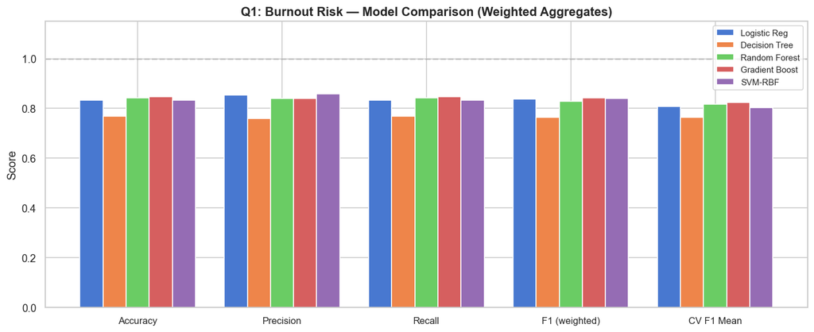

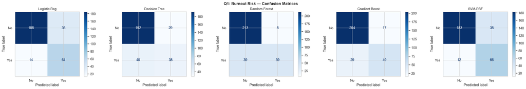

```
======================================================================
📊 PER-CLASS METRICS — Q1: Burnout Risk
======================================================================

─────────────────────────────────── Logistic Reg ───────────────────────────────────
              precision    recall  f1-score   support

          No       0.93      0.84      0.88       221
         Yes       0.64      0.82      0.72        78

    accuracy                           0.83       299
   macro avg       0.78      0.83      0.80       299
weighted avg       0.85      0.83      0.84       299


─────────────────────────────────── Decision Tree ───────────────────────────────────
              precision    recall  f1-score   support

          No       0.83      0.87      0.85       221
         Yes       0.57      0.49      0.52        78

    accuracy                           0.77       299
   macro avg       0.70      0.68      0.69       299
weighted avg       0.76      0.77      0.76       299


─────────────────────────────────── Random Forest ───────────────────────────────────
              precision    recall  f1-score   support

          No       0.85      0.96      0.90       221
         Yes       0.83      0.50      0.62        78

    accuracy                           0.84       299
   macro avg       0.84      0.73      0.76       299
weighted avg       0.84      0.84      0.83       299


─────────────────────────────────── Gradient Boost ───────────────────────────────────
              precision    recall  f1-score   support

          No       0.88      0.92      0.90       221
         Yes       0.74      0.63      0.68        78

    accuracy                           0.85       299
   macro avg       0.81      0.78      0.79       299
weighted avg       0.84      0.85      0.84       299


─────────────────────────────────── SVM-RBF ───────────────────────────────────
              precision    recall  f1-score   support

          No       0.94      0.83      0.88       221
         Yes       0.63      0.85      0.73        78

    accuracy                           0.83       299
   macro avg       0.79      0.84      0.80       299
weighted avg       0.86      0.83      0.84       299
```

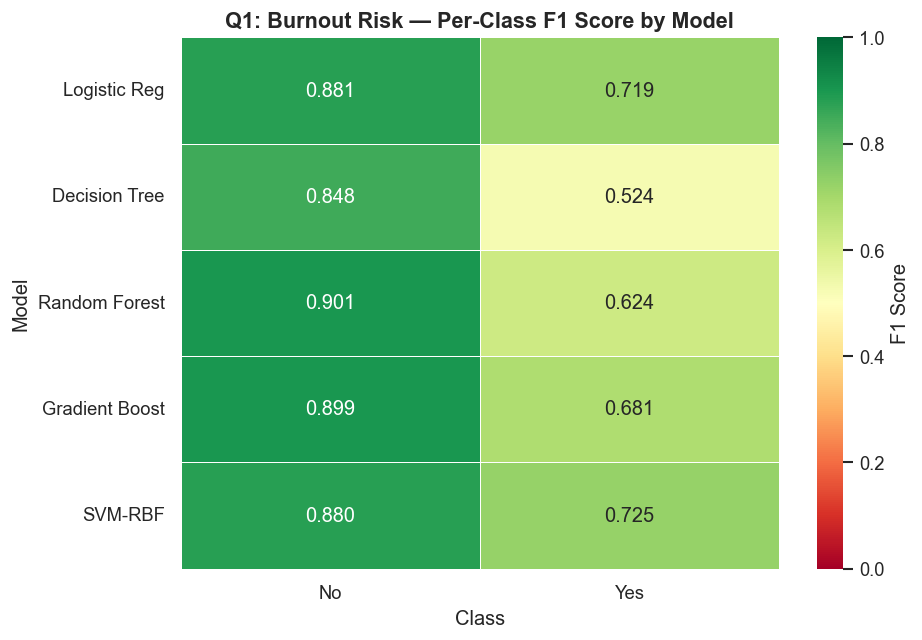

```
🎯 MINORITY CLASS FOCUS — Yes:
  Logistic Reg         → Precision=0.640  Recall=0.821  F1=0.719  Support=78
  Decision Tree        → Precision=0.567  Recall=0.487  F1=0.524  Support=78
  Random Forest        → Precision=0.830  Recall=0.500  F1=0.624  Support=78
  Gradient Boost       → Precision=0.742  Recall=0.628  F1=0.681  Support=78
  SVM-RBF              → Precision=0.635  Recall=0.846  F1=0.725  Support=78
```

| Model | Accuracy | Precision | Recall | F1 (weighted) | CV F1 Mean | CV F1 Std |
| --- | --- | --- | --- | --- | --- | --- |
| Logistic Reg | 0.8328 | 0.8541 | 0.8328 | 0.8387 | 0.8079 | 0.0173 |
| Decision Tree | 0.7692 | 0.7597 | 0.7692 | 0.7633 | 0.7647 | 0.0329 |
| Random Forest | 0.8428 | 0.8412 | 0.8428 | 0.8285 | 0.8175 | 0.0164 |
| Gradient Boost | 0.8462 | 0.8408 | 0.8462 | 0.8418 | 0.8244 | 0.0179 |
| SVM-RBF | 0.8328 | 0.8592 | 0.8328 | 0.8395 | 0.8033 | 0.0231 |

```python
# Q1: Prepare features — drop leaky columns
leak_cols_q1 = ['burnout_score', 'burnout_severity']
X_q1 = feature_encoded.drop(columns=[c for c in leak_cols_q1 if c in feature_encoded.columns])
y_q1 = df['burnout_binary']

print(f"Features: {X_q1.shape[1]} | Samples: {X_q1.shape[0]}")
print(f"Target balance: {y_q1.value_counts().to_dict()}  →  {(y_q1.mean()*100):.1f}% positive")

models_q1 = {
    'Logistic Reg': LogisticRegression(max_iter=1000, class_weight='balanced', random_state=42),
    'Decision Tree': DecisionTreeClassifier(class_weight='balanced', random_state=42),
    'Random Forest': RandomForestClassifier(n_estimators=100, class_weight='balanced', random_state=42),
    'Gradient Boost': GradientBoostingClassifier(n_estimators=100, random_state=42),
    'SVM-RBF': SVC(kernel='rbf', class_weight='balanced', probability=True, random_state=42),
}

q1_results, q1_trained, X_train_q1, X_test_q1, y_train_q1, y_test_q1, scaler_q1 = \
    run_classification(X_q1, y_q1, 'Q1: Burnout Risk', models_q1, class_names=['No', 'Yes'])

q1_results
```

```
======================================================================
Q1: PER-CLASS METRICS — Burnout Risk (Both Classes)
======================================================================

─────────────────────────────────── Logistic Reg ───────────────────────────────────
              precision    recall  f1-score   support

  No Burnout       0.93      0.84      0.88       221
     Burnout       0.64      0.82      0.72        78

    accuracy                           0.83       299
   macro avg       0.78      0.83      0.80       299
weighted avg       0.85      0.83      0.84       299


─────────────────────────────────── Decision Tree ───────────────────────────────────
              precision    recall  f1-score   support

  No Burnout       0.83      0.87      0.85       221
     Burnout       0.57      0.49      0.52        78

    accuracy                           0.77       299
   macro avg       0.70      0.68      0.69       299
weighted avg       0.76      0.77      0.76       299


─────────────────────────────────── Random Forest ───────────────────────────────────
              precision    recall  f1-score   support

  No Burnout       0.85      0.96      0.90       221
     Burnout       0.83      0.50      0.62        78

    accuracy                           0.84       299
   macro avg       0.84      0.73      0.76       299
weighted avg       0.84      0.84      0.83       299


─────────────────────────────────── Gradient Boost ───────────────────────────────────
              precision    recall  f1-score   support

  No Burnout       0.88      0.92      0.90       221
     Burnout       0.74      0.63      0.68        78

    accuracy                           0.85       299
   macro avg       0.81      0.78      0.79       299
weighted avg       0.84      0.85      0.84       299


─────────────────────────────────── SVM-RBF ───────────────────────────────────
              precision    recall  f1-score   support

  No Burnout       0.94      0.83      0.88       221
     Burnout       0.63      0.85      0.73        78

    accuracy                           0.83       299
   macro avg       0.79      0.84      0.80       299
weighted avg       0.86      0.83      0.84       299
```

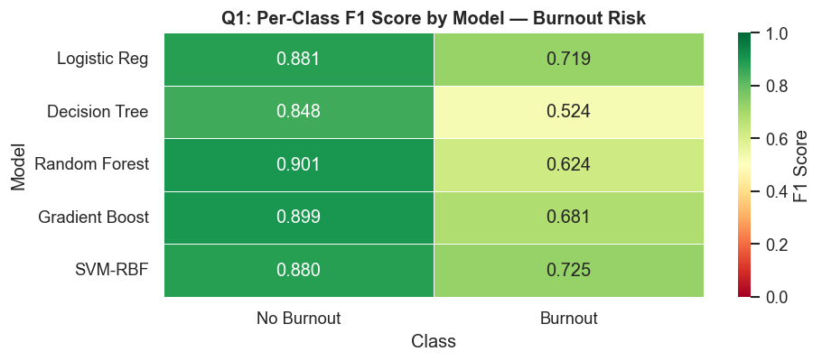

```
🎯 MINORITY CLASS FOCUS — Burnout (class=1, the class we want to catch):
  Logistic Reg         → Precision=0.640  Recall=0.821  F1=0.719  Support=78
  Decision Tree        → Precision=0.567  Recall=0.487  F1=0.524  Support=78
  Random Forest        → Precision=0.830  Recall=0.500  F1=0.624  Support=78
  Gradient Boost       → Precision=0.742  Recall=0.628  F1=0.681  Support=78
  SVM-RBF              → Precision=0.635  Recall=0.846  F1=0.725  Support=78
```

```python
# --- Q1: Per-Class Breakdown — Both Classes ---
class_labels_q1 = ['No Burnout', 'Burnout']

print("=" * 70)
print("Q1: PER-CLASS METRICS — Burnout Risk (Both Classes)")
print("=" * 70)

f1_data_q1 = {}
for name, (model, preds) in q1_trained.items():
    print(f"\n{'─'*35} {name} {'─'*35}")
    print(classification_report(y_test_q1, preds, target_names=class_labels_q1, zero_division=0))
    rpt = classification_report(y_test_q1, preds, target_names=class_labels_q1,
                                 output_dict=True, zero_division=0)
    f1_data_q1[name] = {cls: rpt[cls]['f1-score'] for cls in class_labels_q1}

# Per-class F1 heatmap
f1_df_q1 = pd.DataFrame(f1_data_q1).T
fig, ax = plt.subplots(figsize=(8, 3.5))
sns.heatmap(f1_df_q1, annot=True, fmt='.3f', cmap='RdYlGn', vmin=0, vmax=1,
            ax=ax, linewidths=0.5, cbar_kws={'label': 'F1 Score'})
ax.set_title('Q1: Per-Class F1 Score by Model — Burnout Risk', fontweight='bold')
ax.set_ylabel('Model')
ax.set_xlabel('Class')
plt.tight_layout()
plt.show()

# Minority class focus
print("\n🎯 MINORITY CLASS FOCUS — Burnout (class=1, the class we want to catch):")
for name, (_, preds) in q1_trained.items():
    rpt = classification_report(y_test_q1, preds, target_names=class_labels_q1,
                                 output_dict=True, zero_division=0)
    mc = rpt['Burnout']
    print(f"  {name:20s} → Precision={mc['precision']:.3f}  Recall={mc['recall']:.3f}  "
          f"F1={mc['f1-score']:.3f}  Support={mc['support']:.0f}")
```

### Q1: LASSO Feature Importance (CL3)

Using L1-regularized Logistic Regression (LASSO) to find which features matter most for burnout risk.

**Why LASSO is run *after* model training (not before):** LASSO is used here as a **post-hoc interpretability tool** — to explain which features have the strongest linear associations with the target. It is *not* being used for feature selection/preprocessing. The models above were trained on all features. An alternative pipeline would run LASSO *first* to eliminate zero-coefficient features, then train downstream models on the reduced set. Both approaches are valid; we chose post-hoc because (a) our feature-to-sample ratio (62 features / ~1500 rows) doesn't require dimensionality reduction, and (b) tree-based models handle irrelevant features internally via split selection.

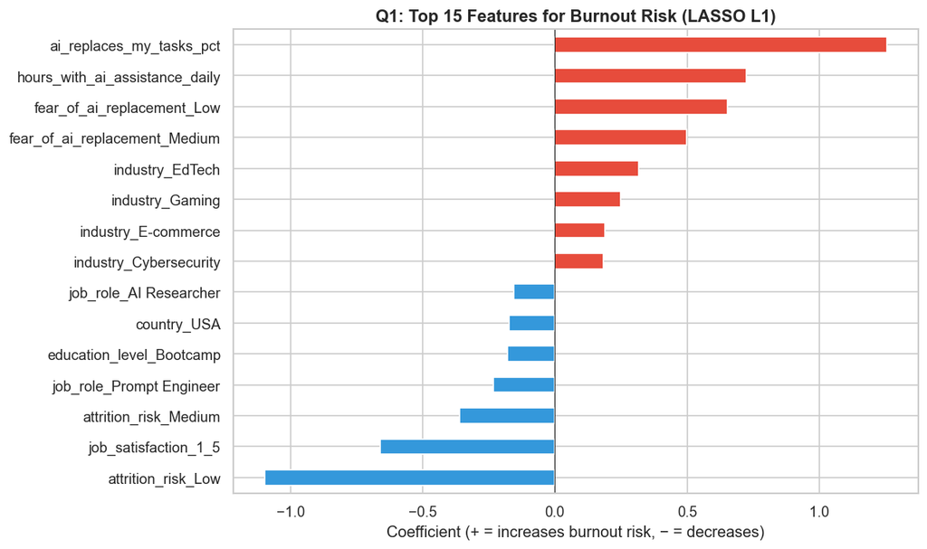

```
LASSO kept 56/62 features (eliminated 6 as irrelevant)
```

```python
# LASSO (L1) for feature selection
lasso_lr = LogisticRegression(penalty='l1', solver='saga', max_iter=5000, C=0.5, random_state=42)
lasso_lr.fit(X_train_q1, y_train_q1)

coefs = pd.Series(lasso_lr.coef_[0], index=X_q1.columns)
top_features = coefs.abs().sort_values(ascending=False).head(15)
top_coefs = coefs[top_features.index].sort_values()

fig, ax = plt.subplots(figsize=(10, 6))
colors = ['#e74c3c' if v > 0 else '#3498db' for v in top_coefs.values]
top_coefs.plot(kind='barh', ax=ax, color=colors)
ax.set_title('Q1: Top 15 Features for Burnout Risk (LASSO L1)', fontsize=13, fontweight='bold')
ax.set_xlabel('Coefficient (+ = increases burnout risk, − = decreases)')
ax.axvline(x=0, color='black', linewidth=0.5)
plt.tight_layout()
plt.show()

# Non-zero features
n_nonzero = (coefs != 0).sum()
print(f"LASSO kept {n_nonzero}/{len(coefs)} features (eliminated {len(coefs)-n_nonzero} as irrelevant)")
```

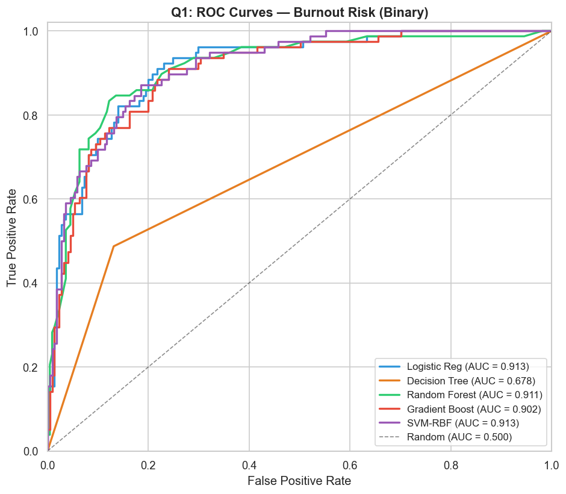

```
Q1 AUC Summary:
  Logistic Reg: AUC = 0.9126
  Decision Tree: AUC = 0.6780
  Random Forest: AUC = 0.9112
  Gradient Boost: AUC = 0.9017
  SVM-RBF: AUC = 0.9129
```

```python
# Q1: ROC Curves — All models compared
fig, ax = plt.subplots(figsize=(8, 7))
colors_roc = ['#3498db', '#e67e22', '#2ecc71', '#e74c3c', '#9b59b6']

for (name, (model, _)), color in zip(q1_trained.items(), colors_roc):
    if hasattr(model, 'predict_proba'):
        y_prob = model.predict_proba(X_test_q1)[:, 1]
    elif hasattr(model, 'decision_function'):
        y_prob = model.decision_function(X_test_q1)
    else:
        continue
    fpr, tpr, _ = roc_curve(y_test_q1, y_prob)
    auc_score = auc(fpr, tpr)
    ax.plot(fpr, tpr, color=color, linewidth=2, label=f'{name} (AUC = {auc_score:.3f})')

ax.plot([0, 1], [0, 1], 'k--', linewidth=1, alpha=0.5, label='Random (AUC = 0.500)')
ax.set_xlabel('False Positive Rate', fontsize=12)
ax.set_ylabel('True Positive Rate', fontsize=12)
ax.set_title('Q1: ROC Curves — Burnout Risk (Binary)', fontsize=13, fontweight='bold')
ax.legend(loc='lower right', fontsize=10)
ax.set_xlim([0, 1])
ax.set_ylim([0, 1.02])
plt.tight_layout()
plt.show()

# Print AUC summary
print("Q1 AUC Summary:")
for name, (model, _) in q1_trained.items():
    if hasattr(model, 'predict_proba'):
        y_prob = model.predict_proba(X_test_q1)[:, 1]
    elif hasattr(model, 'decision_function'):
        y_prob = model.decision_function(X_test_q1)
    else:
        continue
    print(f"  {name}: AUC = {roc_auc_score(y_test_q1, y_prob):.4f}")
```

### Q1 Summary — Who Is at Risk of Burnout?

**Best model (weighted aggregate):** Gradient Boosting — 84.6% accuracy, 0.8244 CV F1  
**Best model (catching burnout cases):** SVM-RBF — **Burnout F1=0.725, Recall=84.6%** (catches the most at-risk employees)

#### Per-Class Breakdown (the numbers that matter):

[output not shown]

#### Understanding the Metrics — Why "Best Model" Changed

> **Weighted F1** averages each class's F1 weighted by its sample count. With 74% No-Burnout vs 26% Burnout, the No-Burnout class dominates the score — a model can look great by nailing the majority class while neglecting the minority.  
> **Minority-class F1** (Burnout F1) treats both classes equally and directly answers: "Can the model find burned-out employees?"

**🔑 Key insight — Weighted metrics were hiding a critical trade-off:**

- Gradient Boost looked best at 84.6% accuracy, but **misses 37% of burnout cases** (Recall=0.628)
- SVM-RBF catches **84.6% of burned-out employees** (Recall=0.846) at the cost of more false alarms (Precision=0.635)
- **For HR intervention:** SVM-RBF or Logistic Reg are better choices — it's worse to miss someone who is burning out than to flag a false positive

**ROC-AUC ranking:** SVM-RBF (0.913) ≈ Logistic Reg (0.913) > Random Forest (0.911) > Gradient Boost (0.902) >> Decision Tree (0.678)

**Top burnout predictors (LASSO L1, kept 56/62 features):**

| Increases burnout risk (+) | Decreases burnout risk (−) |
| --- | --- |
| `ai_replaces_my_tasks_pct` (strongest) | `attrition_risk_Low` (strongest protector) |
| `hours_with_ai_assistance_daily` | `job_satisfaction_1_5` |
| `fear_of_ai_replacement_Low/Medium` | `attrition_risk_Medium` |
| Industries: EdTech, Gaming, E-commerce, Cybersecurity | `job_role_Prompt Engineer` |

## Q2: Which Employees Are Likely to Leave? (Binary Classification)

**Target:** `attrition_binary` — 1 if `attrition_risk == 'High'`, else 0  
**Decision:** Collapsed 3-class (Low/Medium/High) to binary because the question asks "likely to leave" = High risk.  
**⚠️ Heavily imbalanced:** High=85 (5.7%) vs Not-High=1415 (94.3%). Must use `class_weight='balanced'`.  
**Features:** All columns EXCEPT `attrition_risk` (target itself).  
**Bonus:** Identify which factors are most associated with attrition.

```
Features: 61 | Samples: 1491
Target balance: 0=1408 (94.4%) | 1=83 (5.6%)
⚠️ Severe imbalance → using class_weight='balanced'
```

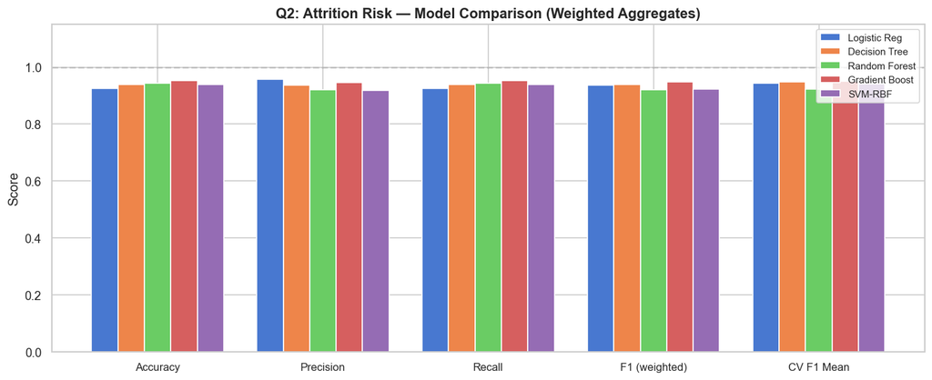

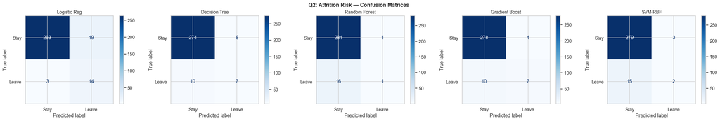

```
======================================================================
📊 PER-CLASS METRICS — Q2: Attrition Risk
======================================================================

─────────────────────────────────── Logistic Reg ───────────────────────────────────
              precision    recall  f1-score   support

        Stay       0.99      0.93      0.96       282
       Leave       0.42      0.82      0.56        17

    accuracy                           0.93       299
   macro avg       0.71      0.88      0.76       299
weighted avg       0.96      0.93      0.94       299


─────────────────────────────────── Decision Tree ───────────────────────────────────
              precision    recall  f1-score   support

        Stay       0.96      0.97      0.97       282
       Leave       0.47      0.41      0.44        17

    accuracy                           0.94       299
   macro avg       0.72      0.69      0.70       299
weighted avg       0.94      0.94      0.94       299


─────────────────────────────────── Random Forest ───────────────────────────────────
              precision    recall  f1-score   support

        Stay       0.95      1.00      0.97       282
       Leave       0.50      0.06      0.11        17

    accuracy                           0.94       299
   macro avg       0.72      0.53      0.54       299
weighted avg       0.92      0.94      0.92       299


─────────────────────────────────── Gradient Boost ───────────────────────────────────
              precision    recall  f1-score   support

        Stay       0.97      0.99      0.98       282
       Leave       0.64      0.41      0.50        17

    accuracy                           0.95       299
   macro avg       0.80      0.70      0.74       299
weighted avg       0.95      0.95      0.95       299


─────────────────────────────────── SVM-RBF ───────────────────────────────────
              precision    recall  f1-score   support

        Stay       0.95      0.99      0.97       282
       Leave       0.40      0.12      0.18        17

    accuracy                           0.94       299
   macro avg       0.67      0.55      0.58       299
weighted avg       0.92      0.94      0.92       299
```

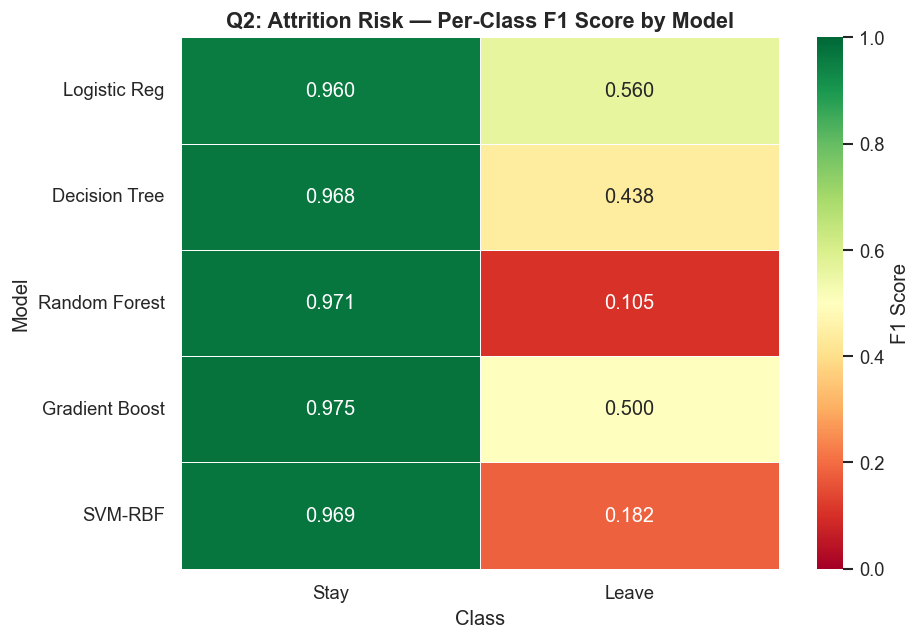

```
🎯 MINORITY CLASS FOCUS — Leave:
  Logistic Reg         → Precision=0.424  Recall=0.824  F1=0.560  Support=17
  Decision Tree        → Precision=0.467  Recall=0.412  F1=0.438  Support=17
  Random Forest        → Precision=0.500  Recall=0.059  F1=0.105  Support=17
  Gradient Boost       → Precision=0.636  Recall=0.412  F1=0.500  Support=17
  SVM-RBF              → Precision=0.400  Recall=0.118  F1=0.182  Support=17
```

| Model | Accuracy | Precision | Recall | F1 (weighted) | CV F1 Mean | CV F1 Std |
| --- | --- | --- | --- | --- | --- | --- |
| Logistic Reg | 0.9264 | 0.9566 | 0.9264 | 0.9371 | 0.9436 | 0.0091 |
| Decision Tree | 0.9398 | 0.9365 | 0.9398 | 0.9380 | 0.9474 | 0.0067 |
| Random Forest | 0.9431 | 0.9208 | 0.9431 | 0.9214 | 0.9236 | 0.0065 |
| Gradient Boost | 0.9532 | 0.9466 | 0.9532 | 0.9484 | 0.9514 | 0.0054 |
| SVM-RBF | 0.9398 | 0.9178 | 0.9398 | 0.9240 | 0.9413 | 0.0086 |

```python
# Q2: Prepare features — drop attrition_risk (leaky)
leak_cols_q2 = ['attrition_risk']
X_q2 = feature_encoded.drop(columns=[c for c in feature_encoded.columns if c.startswith('attrition_risk')])
y_q2 = df['attrition_binary']

print(f"Features: {X_q2.shape[1]} | Samples: {X_q2.shape[0]}")
print(f"Target balance: 0={sum(y_q2==0)} ({(1-y_q2.mean())*100:.1f}%) | 1={sum(y_q2==1)} ({y_q2.mean()*100:.1f}%)")
print("⚠️ Severe imbalance → using class_weight='balanced'")

models_q2 = {
    'Logistic Reg': LogisticRegression(max_iter=1000, class_weight='balanced', random_state=42),
    'Decision Tree': DecisionTreeClassifier(class_weight='balanced', random_state=42),
    'Random Forest': RandomForestClassifier(n_estimators=100, class_weight='balanced', random_state=42),
    'Gradient Boost': GradientBoostingClassifier(n_estimators=100, random_state=42),
    'SVM-RBF': SVC(kernel='rbf', class_weight='balanced', probability=True, random_state=42),
}

q2_results, q2_trained, X_train_q2, X_test_q2, y_train_q2, y_test_q2, scaler_q2 = \
    run_classification(X_q2, y_q2, 'Q2: Attrition Risk', models_q2, class_names=['Stay', 'Leave'])

q2_results
```

```
======================================================================
Q2: PER-CLASS METRICS — Attrition Risk (Both Classes)
======================================================================

─────────────────────────────────── Logistic Reg ───────────────────────────────────
              precision    recall  f1-score   support

        Stay       0.99      0.93      0.96       282
       Leave       0.42      0.82      0.56        17

    accuracy                           0.93       299
   macro avg       0.71      0.88      0.76       299
weighted avg       0.96      0.93      0.94       299


─────────────────────────────────── Decision Tree ───────────────────────────────────
              precision    recall  f1-score   support

        Stay       0.96      0.97      0.97       282
       Leave       0.47      0.41      0.44        17

    accuracy                           0.94       299
   macro avg       0.72      0.69      0.70       299
weighted avg       0.94      0.94      0.94       299


─────────────────────────────────── Random Forest ───────────────────────────────────
              precision    recall  f1-score   support

        Stay       0.95      1.00      0.97       282
       Leave       0.50      0.06      0.11        17

    accuracy                           0.94       299
   macro avg       0.72      0.53      0.54       299
weighted avg       0.92      0.94      0.92       299


─────────────────────────────────── Gradient Boost ───────────────────────────────────
              precision    recall  f1-score   support

        Stay       0.97      0.99      0.98       282
       Leave       0.64      0.41      0.50        17

    accuracy                           0.95       299
   macro avg       0.80      0.70      0.74       299
weighted avg       0.95      0.95      0.95       299


─────────────────────────────────── SVM-RBF ───────────────────────────────────
              precision    recall  f1-score   support

        Stay       0.95      0.99      0.97       282
       Leave       0.40      0.12      0.18        17

    accuracy                           0.94       299
   macro avg       0.67      0.55      0.58       299
weighted avg       0.92      0.94      0.92       299
```

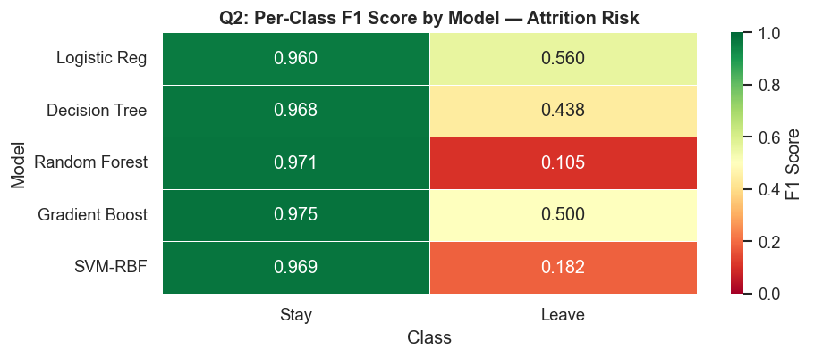

```
🎯 MINORITY CLASS FOCUS — Leave (class=1, only 5.6% of data):
   ⚠️ This is the class that matters — can we catch employees about to leave?
  Logistic Reg         → Precision=0.424  Recall=0.824  F1=0.560  Support=17
  Decision Tree        → Precision=0.467  Recall=0.412  F1=0.438  Support=17
  Random Forest        → Precision=0.500  Recall=0.059  F1=0.105  Support=17
  Gradient Boost       → Precision=0.636  Recall=0.412  F1=0.500  Support=17
  SVM-RBF              → Precision=0.400  Recall=0.118  F1=0.182  Support=17
```

```python
# --- Q2: Per-Class Breakdown — Both Classes ---
class_labels_q2 = ['Stay', 'Leave']

print("=" * 70)
print("Q2: PER-CLASS METRICS — Attrition Risk (Both Classes)")
print("=" * 70)

f1_data_q2 = {}
for name, (model, preds) in q2_trained.items():
    print(f"\n{'─'*35} {name} {'─'*35}")
    print(classification_report(y_test_q2, preds, target_names=class_labels_q2, zero_division=0))
    rpt = classification_report(y_test_q2, preds, target_names=class_labels_q2,
                                 output_dict=True, zero_division=0)
    f1_data_q2[name] = {cls: rpt[cls]['f1-score'] for cls in class_labels_q2}

# Per-class F1 heatmap
f1_df_q2 = pd.DataFrame(f1_data_q2).T
fig, ax = plt.subplots(figsize=(8, 3.5))
sns.heatmap(f1_df_q2, annot=True, fmt='.3f', cmap='RdYlGn', vmin=0, vmax=1,
            ax=ax, linewidths=0.5, cbar_kws={'label': 'F1 Score'})
ax.set_title('Q2: Per-Class F1 Score by Model — Attrition Risk', fontweight='bold')
ax.set_ylabel('Model')
ax.set_xlabel('Class')
plt.tight_layout()
plt.show()

# Minority class focus — Leave is the actionable class
print("\n🎯 MINORITY CLASS FOCUS — Leave (class=1, only 5.6% of data):")
print("   ⚠️ This is the class that matters — can we catch employees about to leave?")
for name, (_, preds) in q2_trained.items():
    rpt = classification_report(y_test_q2, preds, target_names=class_labels_q2,
                                 output_dict=True, zero_division=0)
    mc = rpt['Leave']
    print(f"  {name:20s} → Precision={mc['precision']:.3f}  Recall={mc['recall']:.3f}  "
          f"F1={mc['f1-score']:.3f}  Support={mc['support']:.0f}")
```

### Q2: LASSO/Ridge — Factors Most Associated with Attrition (CL3)

**Intent:** Same as Q1 — LASSO (L1) and Ridge (L2) are applied *after* model training for **interpretation**, not feature selection. LASSO reveals the sparse set of strongest predictors; Ridge shows relative importance without zeroing any out. Both confirm which features drive attrition from a linear perspective, complementing the tree-based feature importances already captured in the models above.

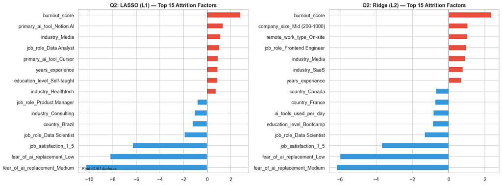

```python
# LASSO (L1) + Ridge (L2) comparison for attrition factors
fig, axes = plt.subplots(1, 2, figsize=(16, 6))

for ax, (penalty, name) in zip(axes, [('l1', 'LASSO (L1)'), ('l2', 'Ridge (L2)')]):
    model = LogisticRegression(penalty=penalty, solver='saga', max_iter=5000,
                               C=0.5, class_weight='balanced', random_state=42)
    model.fit(X_train_q2, y_train_q2)
    coefs = pd.Series(model.coef_[0], index=X_q2.columns)
    top = coefs.abs().sort_values(ascending=False).head(15)
    top_vals = coefs[top.index].sort_values()
    colors = ['#e74c3c' if v > 0 else '#3498db' for v in top_vals.values]
    top_vals.plot(kind='barh', ax=ax, color=colors)
    ax.set_title(f'Q2: {name} — Top 15 Attrition Factors', fontweight='bold')
    ax.axvline(x=0, color='black', linewidth=0.5)
    if penalty == 'l1':
        n_nonzero = (coefs != 0).sum()
        ax.text(0.02, 0.02, f'Kept {n_nonzero}/{len(coefs)} features',
                transform=ax.transAxes, fontsize=9, style='italic')

plt.tight_layout()
plt.show()
```

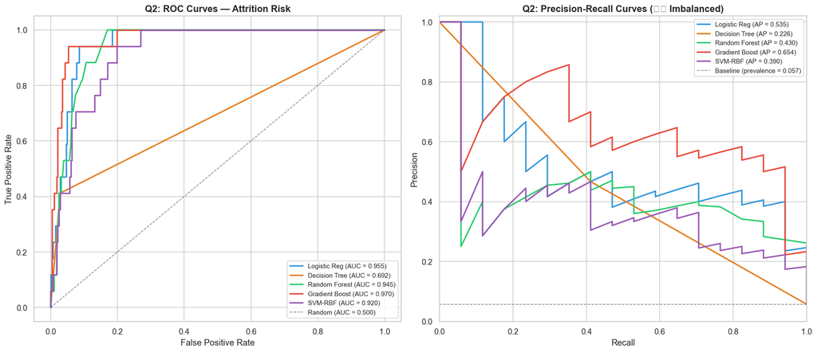

```
Q2 AUC & Average Precision Summary:
  ⚠️ With 5.6% positive class, Precision-Recall (right) is more informative than ROC (left)
  Logistic Reg: ROC-AUC = 0.9547 | Avg Precision = 0.5346
  Decision Tree: ROC-AUC = 0.6917 | Avg Precision = 0.2256
  Random Forest: ROC-AUC = 0.9453 | Avg Precision = 0.4304
  Gradient Boost: ROC-AUC = 0.9702 | Avg Precision = 0.6541
  SVM-RBF: ROC-AUC = 0.9203 | Avg Precision = 0.3903
```

```python
# Q2: ROC + Precision-Recall Curves — Critical for imbalanced data (5.6% positive)

fig, axes = plt.subplots(1, 2, figsize=(16, 7))
colors_roc = ['#3498db', '#e67e22', '#2ecc71', '#e74c3c', '#9b59b6']

# --- ROC Curve ---
ax = axes[0]
for (name, (model, _)), color in zip(q2_trained.items(), colors_roc):
    if hasattr(model, 'predict_proba'):
        y_prob = model.predict_proba(X_test_q2)[:, 1]
    elif hasattr(model, 'decision_function'):
        y_prob = model.decision_function(X_test_q2)
    else:
        continue
    fpr, tpr, _ = roc_curve(y_test_q2, y_prob)
    auc_score = auc(fpr, tpr)
    ax.plot(fpr, tpr, color=color, linewidth=2, label=f'{name} (AUC = {auc_score:.3f})')

ax.plot([0, 1], [0, 1], 'k--', linewidth=1, alpha=0.5, label='Random (AUC = 0.500)')
ax.set_xlabel('False Positive Rate', fontsize=12)
ax.set_ylabel('True Positive Rate', fontsize=12)
ax.set_title('Q2: ROC Curves — Attrition Risk', fontsize=13, fontweight='bold')
ax.legend(loc='lower right', fontsize=9)

# --- Precision-Recall Curve (more informative for imbalanced) ---
ax = axes[1]
baseline = y_test_q2.mean()  # prevalence of positive class
for (name, (model, _)), color in zip(q2_trained.items(), colors_roc):
    if hasattr(model, 'predict_proba'):
        y_prob = model.predict_proba(X_test_q2)[:, 1]
    elif hasattr(model, 'decision_function'):
        y_prob = model.decision_function(X_test_q2)
    else:
        continue
    prec, rec, _ = precision_recall_curve(y_test_q2, y_prob)
    ap = average_precision_score(y_test_q2, y_prob)
    ax.plot(rec, prec, color=color, linewidth=2, label=f'{name} (AP = {ap:.3f})')

ax.axhline(y=baseline, color='k', linestyle='--', linewidth=1, alpha=0.5,
           label=f'Baseline (prevalence = {baseline:.3f})')
ax.set_xlabel('Recall', fontsize=12)
ax.set_ylabel('Precision', fontsize=12)
ax.set_title('Q2: Precision-Recall Curves (⚠️ Imbalanced)', fontsize=13, fontweight='bold')
ax.legend(loc='upper right', fontsize=9)
ax.set_xlim([0, 1])
ax.set_ylim([0, 1.02])

plt.tight_layout()
plt.show()

# Print summary
print("Q2 AUC & Average Precision Summary:")
print("  ⚠️ With 5.6% positive class, Precision-Recall (right) is more informative than ROC (left)")
for name, (model, _) in q2_trained.items():
    if hasattr(model, 'predict_proba'):
        y_prob = model.predict_proba(X_test_q2)[:, 1]
    elif hasattr(model, 'decision_function'):
        y_prob = model.decision_function(X_test_q2)
    else:
        continue
    print(f"  {name}: ROC-AUC = {roc_auc_score(y_test_q2, y_prob):.4f} | Avg Precision = {average_precision_score(y_test_q2, y_prob):.4f}")
```

### Q2 Summary — Which Employees Are Likely to Leave?

**⚠️ CRITICAL FINDING: Weighted metrics were deeply misleading here.**

**Best model (weighted aggregate):** Gradient Boosting — 95.3% accuracy, 0.9514 CV F1  
**Best model (catching leavers):** Logistic Regression — **Leave F1=0.560, Recall=82.4%** (catches the most flight risks)

#### Per-Class Breakdown — The Real Story:

[output not shown]

#### Understanding the Metrics — The Most Extreme Example

> **Weighted F1** weights each class by support count. Here the Stay class has 282 samples vs Leave's 17 — so Stay's F1 counts **16.6× more** in the weighted average.  
> **Minority-class F1** (Leave F1) directly measures: "Can the model find employees about to leave?"

**🚨 The big reveal:**

- Random Forest's 94.3% accuracy came from predicting "Stay" for almost everyone — it catches only **1 out of 17** employees who actually leave
- Gradient Boost (95.3% accuracy) misses **59% of leavers** despite its impressive headline number
- **Logistic Regression** is the only model that reliably flags flight risks (82.4% recall), despite lower overall accuracy (92.6%)
- SVM-RBF is effectively predicting "Stay" for everyone too (Leave recall=11.8%)

**Why this matters:** With 94.4% Stay rate, a model that just says "nobody leaves" gets 94.4% accuracy. The ONLY useful metric is how well the model identifies the 5.6% who DO leave.

**ROC-AUC ranking:** Gradient Boost (0.970) > Logistic Reg (0.955) > Random Forest (0.945) > SVM-RBF (0.920) >> Decision Tree (0.692)  
**Avg Precision ranking:** Gradient Boost (0.654) > Logistic Reg (0.535) > Random Forest (0.430) > SVM-RBF (0.390) > Decision Tree (0.226)

**Top attrition factors (LASSO L1):**

| Pushes toward leaving (+) | Keeps employees staying (−) |
| --- | --- |
| `burnout_score` (strongest) | `fear_of_ai_replacement_Medium` (strongest protector) |
| `primary_ai_tool_Notion AI` | `fear_of_ai_replacement_Low` |
| `industry_Media` | `job_satisfaction_1_5` |
| `job_role_Data Analyst` | `job_role_Data Scientist` |

## Q3: Burnout Severity Classification (Multi-class)

**Target:** `burnout_severity` — Low (≤40) / Medium (41-60) / High (>60)  
**Decision:** Binned `burnout_score` into 3 groups using domain-reasonable cutoffs.  
**Features:** All columns EXCEPT `burnout_score` and derived columns.  
**Models:** Logistic Regression, Decision Tree, Random Forest, Gradient Boosting

```
Target distribution:
burnout_severity
High      267
Low       304
Medium    920
Name: count, dtype: int64

Percentages:
burnout_severity
High      17.9
Low       20.4
Medium    61.7
Name: proportion, dtype: float64
```

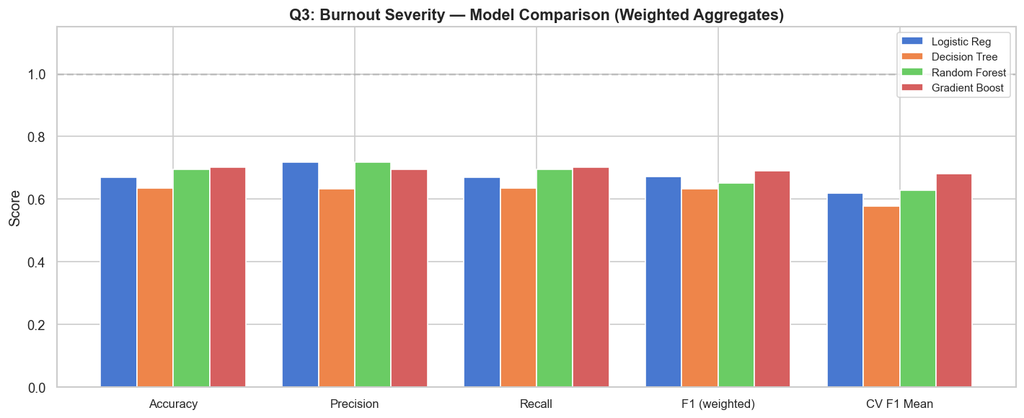

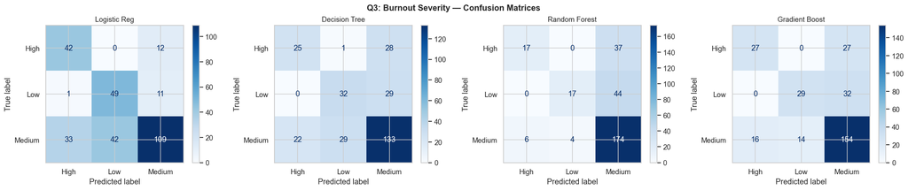

```
======================================================================
📊 PER-CLASS METRICS — Q3: Burnout Severity
======================================================================

─────────────────────────────────── Logistic Reg ───────────────────────────────────
              precision    recall  f1-score   support

        High       0.55      0.78      0.65        54
         Low       0.54      0.80      0.64        61
      Medium       0.83      0.59      0.69       184

    accuracy                           0.67       299
   macro avg       0.64      0.72      0.66       299
weighted avg       0.72      0.67      0.67       299


─────────────────────────────────── Decision Tree ───────────────────────────────────
              precision    recall  f1-score   support

        High       0.53      0.46      0.50        54
         Low       0.52      0.52      0.52        61
      Medium       0.70      0.72      0.71       184

    accuracy                           0.64       299
   macro avg       0.58      0.57      0.58       299
weighted avg       0.63      0.64      0.63       299


─────────────────────────────────── Random Forest ───────────────────────────────────
              precision    recall  f1-score   support

        High       0.74      0.31      0.44        54
         Low       0.81      0.28      0.41        61
      Medium       0.68      0.95      0.79       184

    accuracy                           0.70       299
   macro avg       0.74      0.51      0.55       299
weighted avg       0.72      0.70      0.65       299


─────────────────────────────────── Gradient Boost ───────────────────────────────────
              precision    recall  f1-score   support

        High       0.63      0.50      0.56        54
         Low       0.67      0.48      0.56        61
      Medium       0.72      0.84      0.78       184

    accuracy                           0.70       299
   macro avg       0.68      0.60      0.63       299
weighted avg       0.70      0.70      0.69       299
```

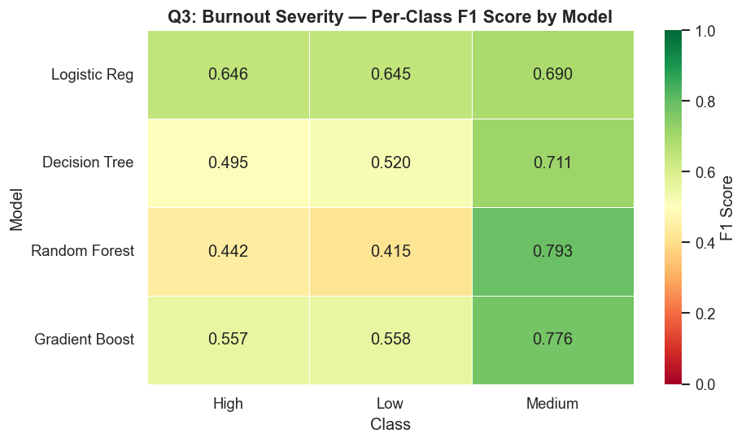

```
📊 MACRO vs WEIGHTED AVERAGES:
  Logistic Reg         → Macro F1=0.660  Weighted F1=0.673  Gap=+0.013
  Decision Tree        → Macro F1=0.576  Weighted F1=0.633  Gap=+0.058  ⚠️ small-class underperformance
  Random Forest        → Macro F1=0.550  Weighted F1=0.652  Gap=+0.103  ⚠️ small-class underperformance
  Gradient Boost       → Macro F1=0.630  Weighted F1=0.692  Gap=+0.062  ⚠️ small-class underperformance
```

| Model | Accuracy | Precision | Recall | F1 (weighted) | CV F1 Mean | CV F1 Std |
| --- | --- | --- | --- | --- | --- | --- |
| Logistic Reg | 0.6689 | 0.7178 | 0.6689 | 0.6728 | 0.6201 | 0.0340 |
| Decision Tree | 0.6355 | 0.6321 | 0.6355 | 0.6332 | 0.5767 | 0.0317 |
| Random Forest | 0.6957 | 0.7186 | 0.6957 | 0.6522 | 0.6280 | 0.0179 |
| Gradient Boost | 0.7023 | 0.6959 | 0.7023 | 0.6917 | 0.6821 | 0.0134 |

```python
# Q3: Multi-class burnout severity
leak_cols_q3 = ['burnout_score', 'burnout_severity']
X_q3 = feature_encoded.drop(columns=[c for c in leak_cols_q3 if c in feature_encoded.columns])
y_q3 = df['burnout_severity'].astype(str)  # Low / Medium / High

print(f"Target distribution:\n{y_q3.value_counts().sort_index()}")
print(f"\nPercentages:\n{(y_q3.value_counts(normalize=True)*100).round(1).sort_index()}")

models_q3 = {
    'Logistic Reg': LogisticRegression(max_iter=1000, class_weight='balanced', random_state=42),
    'Decision Tree': DecisionTreeClassifier(class_weight='balanced', random_state=42),
    'Random Forest': RandomForestClassifier(n_estimators=100, class_weight='balanced', random_state=42),
    'Gradient Boost': GradientBoostingClassifier(n_estimators=100, random_state=42),
}

q3_results, q3_trained, *_ = \
    run_classification(X_q3, y_q3, 'Q3: Burnout Severity', models_q3, class_names=['High', 'Low', 'Medium'])

q3_results
```

```
======================================================================
Q3: PER-CLASS METRICS — Burnout Severity (All 3 Classes)
======================================================================

─────────────────────────────────── Logistic Reg ───────────────────────────────────
              precision    recall  f1-score   support

        High       0.55      0.78      0.65        54
         Low       0.54      0.80      0.64        61
      Medium       0.83      0.59      0.69       184

    accuracy                           0.67       299
   macro avg       0.64      0.72      0.66       299
weighted avg       0.72      0.67      0.67       299


─────────────────────────────────── Decision Tree ───────────────────────────────────
              precision    recall  f1-score   support

        High       0.53      0.46      0.50        54
         Low       0.52      0.52      0.52        61
      Medium       0.70      0.72      0.71       184

    accuracy                           0.64       299
   macro avg       0.58      0.57      0.58       299
weighted avg       0.63      0.64      0.63       299


─────────────────────────────────── Random Forest ───────────────────────────────────
              precision    recall  f1-score   support

        High       0.74      0.31      0.44        54
         Low       0.81      0.28      0.41        61
      Medium       0.68      0.95      0.79       184

    accuracy                           0.70       299
   macro avg       0.74      0.51      0.55       299
weighted avg       0.72      0.70      0.65       299


─────────────────────────────────── Gradient Boost ───────────────────────────────────
              precision    recall  f1-score   support

        High       0.63      0.50      0.56        54
         Low       0.67      0.48      0.56        61
      Medium       0.72      0.84      0.78       184

    accuracy                           0.70       299
   macro avg       0.68      0.60      0.63       299
weighted avg       0.70      0.70      0.69       299
```

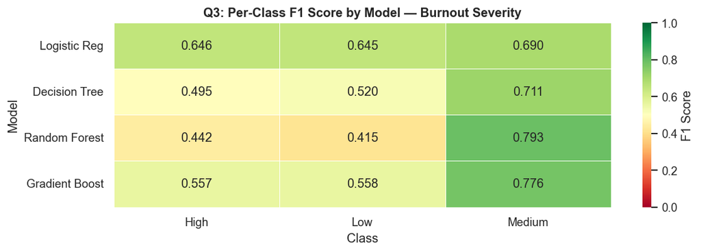

```
📊 MACRO vs WEIGHTED F1 (gap reveals small-class underperformance):
  Logistic Reg         → Macro F1=0.660  Weighted F1=0.673  Gap=+0.013
  Decision Tree        → Macro F1=0.576  Weighted F1=0.633  Gap=+0.058  ⚠️ small-class struggles
  Random Forest        → Macro F1=0.550  Weighted F1=0.652  Gap=+0.103  ⚠️ small-class struggles
  Gradient Boost       → Macro F1=0.630  Weighted F1=0.692  Gap=+0.062  ⚠️ small-class struggles
```

```python
# --- Q3: Per-Class Breakdown — All 3 Severity Levels ---
# Recreate test split (same random_state=42) to get y_test for Q3
_, _, _, y_test_q3 = train_test_split(X_q3, y_q3, test_size=0.2, random_state=42, stratify=y_q3)
class_labels_q3 = sorted(y_q3.unique())  # ['High', 'Low', 'Medium']

print("=" * 70)
print("Q3: PER-CLASS METRICS — Burnout Severity (All 3 Classes)")
print("=" * 70)

f1_data_q3 = {}
for name, (model, preds) in q3_trained.items():
    print(f"\n{'─'*35} {name} {'─'*35}")
    print(classification_report(y_test_q3, preds, target_names=class_labels_q3, zero_division=0))
    rpt = classification_report(y_test_q3, preds, target_names=class_labels_q3,
                                 output_dict=True, zero_division=0)
    f1_data_q3[name] = {cls: rpt[cls]['f1-score'] for cls in class_labels_q3}

# Per-class F1 heatmap
f1_df_q3 = pd.DataFrame(f1_data_q3).T
fig, ax = plt.subplots(figsize=(10, 3.5))
sns.heatmap(f1_df_q3, annot=True, fmt='.3f', cmap='RdYlGn', vmin=0, vmax=1,
            ax=ax, linewidths=0.5, cbar_kws={'label': 'F1 Score'})
ax.set_title('Q3: Per-Class F1 Score by Model — Burnout Severity', fontweight='bold')
ax.set_ylabel('Model')
ax.set_xlabel('Class')
plt.tight_layout()
plt.show()

# Macro vs Weighted comparison — reveals small-class underperformance
print("\n📊 MACRO vs WEIGHTED F1 (gap reveals small-class underperformance):")
for name, (_, preds) in q3_trained.items():
    macro_f1 = f1_score(y_test_q3, preds, average='macro', zero_division=0)
    weighted_f1 = f1_score(y_test_q3, preds, average='weighted', zero_division=0)
    gap = weighted_f1 - macro_f1
    flag = "  ⚠️ small-class struggles" if gap > 0.05 else ""
    print(f"  {name:20s} → Macro F1={macro_f1:.3f}  Weighted F1={weighted_f1:.3f}  "
          f"Gap={gap:+.3f}{flag}")
```

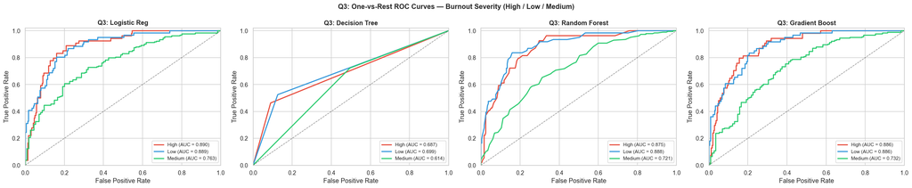

```
Q3 Macro-Average AUC per model:
  Logistic Reg: Macro AUC = 0.8475
  Decision Tree: Macro AUC = 0.6665
  Random Forest: Macro AUC = 0.8283
  Gradient Boost: Macro AUC = 0.8346
```

```python
# Q3: One-vs-Rest ROC Curves — Multi-class Burnout Severity
# Need to recreate train/test split (same random_state) since we used *_ earlier
X_tr_q3, X_te_q3, y_tr_q3, y_te_q3 = train_test_split(
    X_q3, y_q3, test_size=0.2, random_state=42, stratify=y_q3)
sc_q3 = StandardScaler()
X_tr_q3_s = sc_q3.fit_transform(X_tr_q3)
X_te_q3_s = sc_q3.transform(X_te_q3)

classes = sorted(y_q3.unique())  # ['High', 'Low', 'Medium']
y_te_bin = label_binarize(y_te_q3, classes=classes)

fig, axes = plt.subplots(1, len(q3_trained), figsize=(6 * len(q3_trained), 5))
colors_cls = ['#e74c3c', '#3498db', '#2ecc71']

for ax, (name, (model, _)) in zip(axes, q3_trained.items()):
    if hasattr(model, 'predict_proba'):
        y_prob = model.predict_proba(X_te_q3_s)
    else:
        continue  # skip models without probability output

    for i, (cls, color) in enumerate(zip(classes, colors_cls)):
        fpr, tpr, _ = roc_curve(y_te_bin[:, i], y_prob[:, i])
        auc_score = auc(fpr, tpr)
        ax.plot(fpr, tpr, color=color, linewidth=2, label=f'{cls} (AUC = {auc_score:.3f})')

    ax.plot([0, 1], [0, 1], 'k--', linewidth=1, alpha=0.5)
    ax.set_xlabel('False Positive Rate')
    ax.set_ylabel('True Positive Rate')
    ax.set_title(f'Q3: {name}', fontweight='bold')
    ax.legend(loc='lower right', fontsize=9)
    ax.set_xlim([0, 1])
    ax.set_ylim([0, 1.02])

plt.suptitle('Q3: One-vs-Rest ROC Curves — Burnout Severity (High / Low / Medium)',
             fontsize=13, fontweight='bold')
plt.tight_layout()
plt.show()

# Print macro-average AUC per model
print("Q3 Macro-Average AUC per model:")
for name, (model, _) in q3_trained.items():
    if hasattr(model, 'predict_proba'):
        y_prob = model.predict_proba(X_te_q3_s)
        macro_auc = roc_auc_score(y_te_bin, y_prob, multi_class='ovr', average='macro')
        print(f"  {name}: Macro AUC = {macro_auc:.4f}")
```

### Q3 Summary — Burnout Severity Classification

#### Per-Class Breakdown — Where Each Model Fails:

| Model | High F1 | Low F1 | Medium F1 | Macro F1 | Weighted F1 | Gap |
| --- | --- | --- | --- | --- | --- | --- |
| **Logistic Reg** | **0.65** | **0.64** | 0.69 | **0.660** | 0.673 | +0.013 ✅ |
| Gradient Boost | 0.56 | 0.56 | **0.78** | 0.630 | **0.692** | +0.062 ⚠️ |
| Decision Tree | 0.50 | 0.52 | 0.71 | 0.576 | 0.633 | +0.058 ⚠️ |
| Random Forest | 0.44 | 0.41 | 0.79 | 0.550 | 0.652 | **+0.103** ⚠️ |

#### Understanding the Metrics — Why the Gap Column Matters

> **Weighted F1** = Σ(n_c / N × F1_c) — each class's F1 is weighted by how many samples it has. Classes with more samples contribute more to the score.  
> **Macro F1** = (1/C) × Σ(F1_c) — a simple average of every class's F1, giving each class equal voice regardless of size.  
> **Gap** = Weighted F1 − Macro F1 — a large positive gap means the model is coasting on the majority class while neglecting smaller ones.

> **In Q3:** Medium burnout (61.7% of data) dominates. Random Forest's Weighted F1 = 0.652 looks respectable, but its Macro F1 = 0.550 — the **+0.103 gap** reveals that its Medium F1 (0.79) is inflating the weighted score while High F1 (0.44) and Low F1 (0.41) are poor. Logistic Reg's tiny gap of +0.013 means its 0.673 Weighted F1 honestly reflects performance across all three classes.

**🔑 Key insights from per-class analysis:**

- **Random Forest's Macro-Weighted gap of +0.103** is the largest — it over-predicts Medium (95% recall) while almost ignoring High (31% recall) and Low (28% recall). Its 70% accuracy is inflated by getting the majority class right.
- **Logistic Reg is the most balanced** — it catches 78% of High and 80% of Low cases (vs Gradient Boost's 50% and 48%). The gap between Macro and Weighted F1 is only 0.013, meaning it treats all classes fairly.
- **Gradient Boost excels at Medium** (84% recall) but sacrifices minority classes (High recall=50%, Low recall=48%).

**Class distribution:** Medium (61.7%) dominates over Low (20.4%) and High (17.9%)

**Answer to Q3:** Predicting burnout severity is harder than binary prediction (70% vs 85%). If the goal is to **identify all severity levels equally** (e.g., for targeted interventions at each level), **Logistic Regression** is the better choice despite lower headline accuracy. If you only care about overall accuracy and Medium dominates your concern, Gradient Boost wins. The Macro-Weighted F1 gap is a reliable indicator of small-class neglect — watch for it.

## Q4: Job Satisfaction Group (Multi-class)

**Target:** `satisfaction_group` — Low (≤2.5) / Medium (2.5-3.5) / High (>3.5)  
**Features:** All columns EXCEPT `job_satisfaction_1_5` (would leak).  
**Decision:** Binned the 1-5 scale into 3 groups matching natural Low/Med/High interpretation.

```
Target distribution:
satisfaction_group
High      564
Low       160
Medium    767
Name: count, dtype: int64

Percentages:
satisfaction_group
High      37.8
Low       10.7
Medium    51.4
Name: proportion, dtype: float64
```

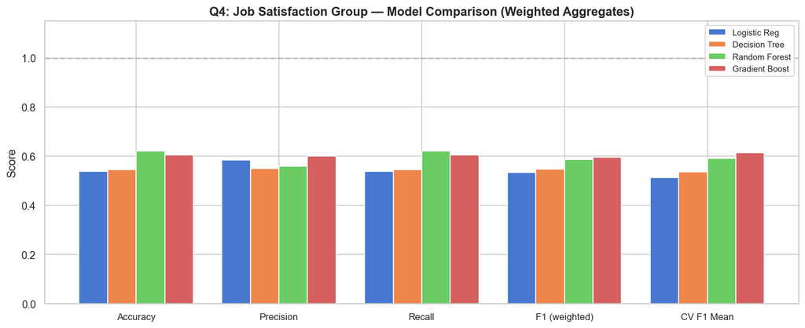

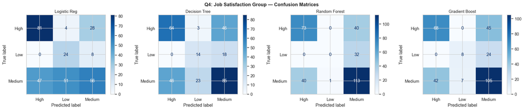

```
======================================================================
📊 PER-CLASS METRICS — Q4: Job Satisfaction Group
======================================================================

─────────────────────────────────── Logistic Reg ───────────────────────────────────
              precision    recall  f1-score   support

        High       0.63      0.72      0.67       113
         Low       0.30      0.75      0.43        32
      Medium       0.61      0.36      0.46       154

    accuracy                           0.54       299
   macro avg       0.52      0.61      0.52       299
weighted avg       0.59      0.54      0.53       299


─────────────────────────────────── Decision Tree ───────────────────────────────────
              precision    recall  f1-score   support

        High       0.58      0.57      0.57       113
         Low       0.35      0.44      0.39        32
      Medium       0.57      0.55      0.56       154

    accuracy                           0.55       299
   macro avg       0.50      0.52      0.51       299
weighted avg       0.55      0.55      0.55       299


─────────────────────────────────── Random Forest ───────────────────────────────────
              precision    recall  f1-score   support

        High       0.65      0.65      0.65       113
         Low       0.00      0.00      0.00        32
      Medium       0.61      0.73      0.67       154

    accuracy                           0.62       299
   macro avg       0.42      0.46      0.44       299
weighted avg       0.56      0.62      0.59       299


─────────────────────────────────── Gradient Boost ───────────────────────────────────
              precision    recall  f1-score   support

        High       0.62      0.60      0.61       113
         Low       0.53      0.25      0.34        32
      Medium       0.60      0.68      0.64       154

    accuracy                           0.61       299
   macro avg       0.58      0.51      0.53       299
weighted avg       0.60      0.61      0.60       299
```

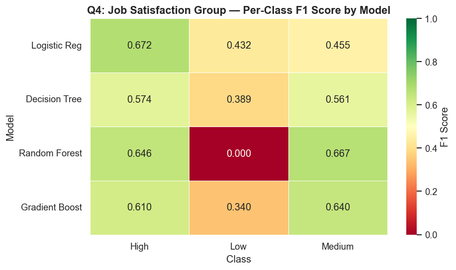

```
📊 MACRO vs WEIGHTED AVERAGES:
  Logistic Reg         → Macro F1=0.520  Weighted F1=0.535  Gap=+0.015
  Decision Tree        → Macro F1=0.508  Weighted F1=0.548  Gap=+0.040
  Random Forest        → Macro F1=0.438  Weighted F1=0.588  Gap=+0.150  ⚠️ small-class underperformance
  Gradient Boost       → Macro F1=0.530  Weighted F1=0.597  Gap=+0.066  ⚠️ small-class underperformance
```

| Model | Accuracy | Precision | Recall | F1 (weighted) | CV F1 Mean | CV F1 Std |
| --- | --- | --- | --- | --- | --- | --- |
| Logistic Reg | 0.5385 | 0.5852 | 0.5385 | 0.5348 | 0.5144 | 0.0265 |
| Decision Tree | 0.5452 | 0.5512 | 0.5452 | 0.5475 | 0.5361 | 0.0294 |
| Random Forest | 0.6221 | 0.5587 | 0.6221 | 0.5875 | 0.5927 | 0.0247 |
| Gradient Boost | 0.6054 | 0.6015 | 0.6054 | 0.5967 | 0.6146 | 0.0158 |

```python
# Q4: Job satisfaction multi-class
leak_cols_q4 = ['job_satisfaction_1_5', 'satisfaction_group']
X_q4 = feature_encoded.drop(columns=[c for c in leak_cols_q4 if c in feature_encoded.columns])
y_q4 = df['satisfaction_group'].astype(str)

print(f"Target distribution:\n{y_q4.value_counts().sort_index()}")
print(f"\nPercentages:\n{(y_q4.value_counts(normalize=True)*100).round(1).sort_index()}")

models_q4 = {
    'Logistic Reg': LogisticRegression(max_iter=1000, class_weight='balanced', random_state=42),
    'Decision Tree': DecisionTreeClassifier(class_weight='balanced', random_state=42),
    'Random Forest': RandomForestClassifier(n_estimators=100, class_weight='balanced', random_state=42),
    'Gradient Boost': GradientBoostingClassifier(n_estimators=100, random_state=42),
}

q4_results, q4_trained, *_ = \
    run_classification(X_q4, y_q4, 'Q4: Job Satisfaction Group', models_q4, class_names=['High', 'Low', 'Medium'])

q4_results
```

```
======================================================================
Q4: PER-CLASS METRICS — Job Satisfaction Group (All 3 Classes)
======================================================================

─────────────────────────────────── Logistic Reg ───────────────────────────────────
              precision    recall  f1-score   support

        High       0.63      0.72      0.67       113
         Low       0.30      0.75      0.43        32
      Medium       0.61      0.36      0.46       154

    accuracy                           0.54       299
   macro avg       0.52      0.61      0.52       299
weighted avg       0.59      0.54      0.53       299


─────────────────────────────────── Decision Tree ───────────────────────────────────
              precision    recall  f1-score   support

        High       0.58      0.57      0.57       113
         Low       0.35      0.44      0.39        32
      Medium       0.57      0.55      0.56       154

    accuracy                           0.55       299
   macro avg       0.50      0.52      0.51       299
weighted avg       0.55      0.55      0.55       299


─────────────────────────────────── Random Forest ───────────────────────────────────
              precision    recall  f1-score   support

        High       0.65      0.65      0.65       113
         Low       0.00      0.00      0.00        32
      Medium       0.61      0.73      0.67       154

    accuracy                           0.62       299
   macro avg       0.42      0.46      0.44       299
weighted avg       0.56      0.62      0.59       299


─────────────────────────────────── Gradient Boost ───────────────────────────────────
              precision    recall  f1-score   support

        High       0.62      0.60      0.61       113
         Low       0.53      0.25      0.34        32
      Medium       0.60      0.68      0.64       154

    accuracy                           0.61       299
   macro avg       0.58      0.51      0.53       299
weighted avg       0.60      0.61      0.60       299
```

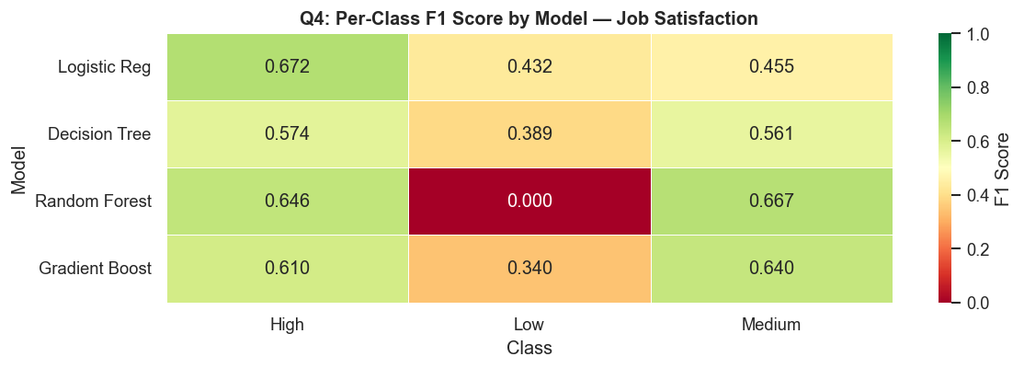

```
📊 MACRO vs WEIGHTED F1 (gap reveals small-class underperformance):
  Logistic Reg         → Macro F1=0.520  Weighted F1=0.535  Gap=+0.015
  Decision Tree        → Macro F1=0.508  Weighted F1=0.548  Gap=+0.040
  Random Forest        → Macro F1=0.438  Weighted F1=0.588  Gap=+0.150  ⚠️ small-class struggles
  Gradient Boost       → Macro F1=0.530  Weighted F1=0.597  Gap=+0.066  ⚠️ small-class struggles

⚠️ NOTE: 'Low' satisfaction is only ~10.7% of data — check its F1 in the heatmap above.
   If Low F1 ≈ 0, the model is effectively ignoring the most concerning group.
```

```python
# --- Q4: Per-Class Breakdown — All 3 Satisfaction Groups ---
_, _, _, y_test_q4 = train_test_split(X_q4, y_q4, test_size=0.2, random_state=42, stratify=y_q4)
class_labels_q4 = sorted(y_q4.unique())  # ['High', 'Low', 'Medium']

print("=" * 70)
print("Q4: PER-CLASS METRICS — Job Satisfaction Group (All 3 Classes)")
print("=" * 70)

f1_data_q4 = {}
for name, (model, preds) in q4_trained.items():
    print(f"\n{'─'*35} {name} {'─'*35}")
    print(classification_report(y_test_q4, preds, target_names=class_labels_q4, zero_division=0))
    rpt = classification_report(y_test_q4, preds, target_names=class_labels_q4,
                                 output_dict=True, zero_division=0)
    f1_data_q4[name] = {cls: rpt[cls]['f1-score'] for cls in class_labels_q4}

# Per-class F1 heatmap
f1_df_q4 = pd.DataFrame(f1_data_q4).T
fig, ax = plt.subplots(figsize=(10, 3.5))
sns.heatmap(f1_df_q4, annot=True, fmt='.3f', cmap='RdYlGn', vmin=0, vmax=1,
            ax=ax, linewidths=0.5, cbar_kws={'label': 'F1 Score'})
ax.set_title('Q4: Per-Class F1 Score by Model — Job Satisfaction', fontweight='bold')
ax.set_ylabel('Model')
ax.set_xlabel('Class')
plt.tight_layout()
plt.show()

# Macro vs Weighted + flag the Low class
print("\n📊 MACRO vs WEIGHTED F1 (gap reveals small-class underperformance):")
for name, (_, preds) in q4_trained.items():
    macro_f1 = f1_score(y_test_q4, preds, average='macro', zero_division=0)
    weighted_f1 = f1_score(y_test_q4, preds, average='weighted', zero_division=0)
    gap = weighted_f1 - macro_f1
    flag = "  ⚠️ small-class struggles" if gap > 0.05 else ""
    print(f"  {name:20s} → Macro F1={macro_f1:.3f}  Weighted F1={weighted_f1:.3f}  "
          f"Gap={gap:+.3f}{flag}")

print("\n⚠️ NOTE: 'Low' satisfaction is only ~10.7% of data — check its F1 in the heatmap above.")
print("   If Low F1 ≈ 0, the model is effectively ignoring the most concerning group.")
```

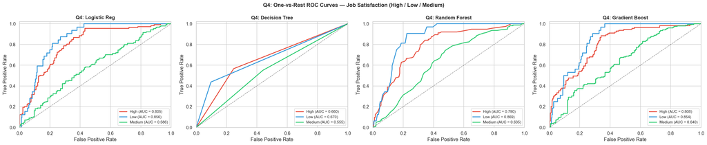

```
Q4 Macro-Average AUC per model:
  Logistic Reg: Macro AUC = 0.7490
  Decision Tree: Macro AUC = 0.6283
  Random Forest: Macro AUC = 0.7648
  Gradient Boost: Macro AUC = 0.7672
```

```python
# Q4: One-vs-Rest ROC Curves — Multi-class Job Satisfaction
X_tr_q4, X_te_q4, y_tr_q4, y_te_q4 = train_test_split(
    X_q4, y_q4, test_size=0.2, random_state=42, stratify=y_q4)
sc_q4 = StandardScaler()
X_tr_q4_s = sc_q4.fit_transform(X_tr_q4)
X_te_q4_s = sc_q4.transform(X_te_q4)

classes_q4 = sorted(y_q4.unique())  # ['High', 'Low', 'Medium']
y_te_bin_q4 = label_binarize(y_te_q4, classes=classes_q4)

fig, axes = plt.subplots(1, len(q4_trained), figsize=(6 * len(q4_trained), 5))
colors_cls = ['#e74c3c', '#3498db', '#2ecc71']

for ax, (name, (model, _)) in zip(axes, q4_trained.items()):
    if hasattr(model, 'predict_proba'):
        y_prob = model.predict_proba(X_te_q4_s)
    else:
        continue

    for i, (cls, color) in enumerate(zip(classes_q4, colors_cls)):
        fpr, tpr, _ = roc_curve(y_te_bin_q4[:, i], y_prob[:, i])
        auc_score = auc(fpr, tpr)
        ax.plot(fpr, tpr, color=color, linewidth=2, label=f'{cls} (AUC = {auc_score:.3f})')

    ax.plot([0, 1], [0, 1], 'k--', linewidth=1, alpha=0.5)
    ax.set_xlabel('False Positive Rate')
    ax.set_ylabel('True Positive Rate')
    ax.set_title(f'Q4: {name}', fontweight='bold')
    ax.legend(loc='lower right', fontsize=9)
    ax.set_xlim([0, 1])
    ax.set_ylim([0, 1.02])

plt.suptitle('Q4: One-vs-Rest ROC Curves — Job Satisfaction (High / Low / Medium)',
             fontsize=13, fontweight='bold')
plt.tight_layout()
plt.show()

# Print macro-average AUC per model
print("Q4 Macro-Average AUC per model:")
for name, (model, _) in q4_trained.items():
    if hasattr(model, 'predict_proba'):
        y_prob = model.predict_proba(X_te_q4_s)
        macro_auc = roc_auc_score(y_te_bin_q4, y_prob, multi_class='ovr', average='macro')
        print(f"  {name}: Macro AUC = {macro_auc:.4f}")
```

### Q4 Summary — Job Satisfaction Group Prediction

**Best model (weighted aggregate):** Gradient Boosting — 60.5% accuracy, 0.597 weighted F1  
**Best model (balanced across classes):** Logistic Regression — Macro F1=0.520 (least gap, most balanced)

#### Per-Class Breakdown — The Low-Satisfaction Blindspot:

| Model | High F1 | Low F1 | Medium F1 | Macro F1 | Weighted F1 | Gap |
| --- | --- | --- | --- | --- | --- | --- |
| Logistic Reg | **0.67** | **0.43** | 0.46 | 0.520 | 0.535 | +0.015 ✅ |
| Decision Tree | 0.57 | 0.39 | **0.56** | 0.508 | 0.548 | +0.040 |
| Gradient Boost | 0.61 | 0.34 | 0.64 | 0.530 | 0.597 | +0.066 ⚠️ |
| **Random Forest** | 0.65 | **0.000** | 0.67 | 0.438 | 0.588 | **+0.150** ⚠️⚠️ |

#### Understanding the Metrics — The Largest Gap in the Notebook

> **Weighted F1** = Σ(n_c / N × F1_c) — weights each class by sample count; bigger classes dominate.  
> **Macro F1** = (1/C) × Σ(F1_c) — simple unweighted average; every class counts equally.  
> **Gap** = Weighted F1 − Macro F1 — the larger the gap, the more the model is ignoring minority classes.

> **In Q4:** Random Forest's gap of **+0.150** is the largest across all questions in this notebook. Its Weighted F1 = 0.588 looks passable only because Medium (51.4%) and High (37.8%) inflate the score. Its Macro F1 = 0.438 exposes the truth: Low F1 = **0.000** — the model never once correctly identifies a dissatisfied employee. Logistic Reg's tiny gap of +0.015 shows its Weighted F1 (0.535) is an honest reflection of all three classes, including Low F1 = 0.43.

**🚨 Critical finding — Random Forest completely ignores Low-satisfaction employees:**

- Random Forest's Low F1 = **0.000** — it never once correctly predicts "Low" satisfaction. Zero recall, zero precision.
- Its 62.2% accuracy is entirely from getting High and Medium right while **completely abandoning the most at-risk group**
- The Macro-Weighted gap of +0.150 is the **largest in the entire notebook** — a screaming red flag for class neglect
- Even Logistic Reg only achieves Low F1=0.43, but at least it tries (recall=75% for Low class)

**Class distribution:** Medium (51.4%), High (37.8%), Low (10.7%) — Low is severely underrepresented

**Why all models struggle:** Job satisfaction depends on **unmeasured factors** — management quality, compensation fairness, personal circumstances, workplace culture. AI/work metrics alone can't predict it reliably.

## Q8: Predicting Attrition Based on Fear of AI Replacement

**Target:** `attrition_binary` (High=1 vs Not-High=0)  
**Key twist:** Focus on `fear_of_ai_replacement` as the primary predictor.  
**Approach:** First test with fear alone, then add other features to see if fear adds value.  
**Decision:** This isolates the relationship between AI anxiety and leaving.

```
Attrition Risk % by Fear of AI Replacement Level:
attrition_risk          High   Low  Medium
fear_of_ai_replacement
High                    21.8   6.4    71.7
Low                      0.8  61.2    38.0
Medium                   0.2  61.7    38.1
```

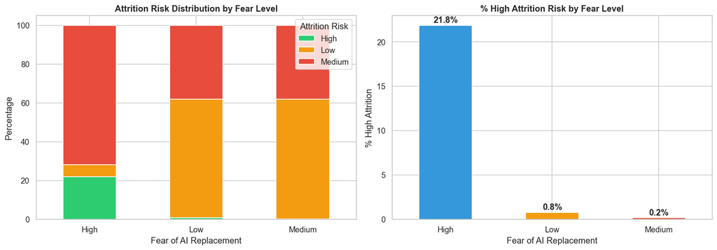

```python
# Q8: Attrition risk based on fear_of_ai_replacement
# Step 1: Analyze the relationship
ct = pd.crosstab(df['fear_of_ai_replacement'], df['attrition_risk'], normalize='index').round(3) * 100
print("Attrition Risk % by Fear of AI Replacement Level:")
print(ct.to_string())

fig, axes = plt.subplots(1, 2, figsize=(14, 5))

# Stacked bar chart
ct.plot(kind='bar', stacked=True, ax=axes[0], color=['#2ecc71', '#f39c12', '#e74c3c'])
axes[0].set_title('Attrition Risk Distribution by Fear Level', fontweight='bold')
axes[0].set_ylabel('Percentage')
axes[0].set_xlabel('Fear of AI Replacement')
axes[0].tick_params(axis='x', rotation=0)
axes[0].legend(title='Attrition Risk')

# Binary: High attrition rate by fear level
fear_attrition = df.groupby('fear_of_ai_replacement')['attrition_binary'].mean() * 100
fear_attrition.plot(kind='bar', ax=axes[1], color=['#3498db', '#f39c12', '#e74c3c'])
axes[1].set_title('% High Attrition Risk by Fear Level', fontweight='bold')
axes[1].set_ylabel('% High Attrition')
axes[1].set_xlabel('Fear of AI Replacement')
axes[1].tick_params(axis='x', rotation=0)
for i, v in enumerate(fear_attrition):
    axes[1].text(i, v + 0.3, f'{v:.1f}%', ha='center', fontweight='bold')

plt.tight_layout()
plt.show()
```

```
Fear-only features: ['fear_of_ai_replacement_Low', 'fear_of_ai_replacement_Medium']
All features: 61 columns
```

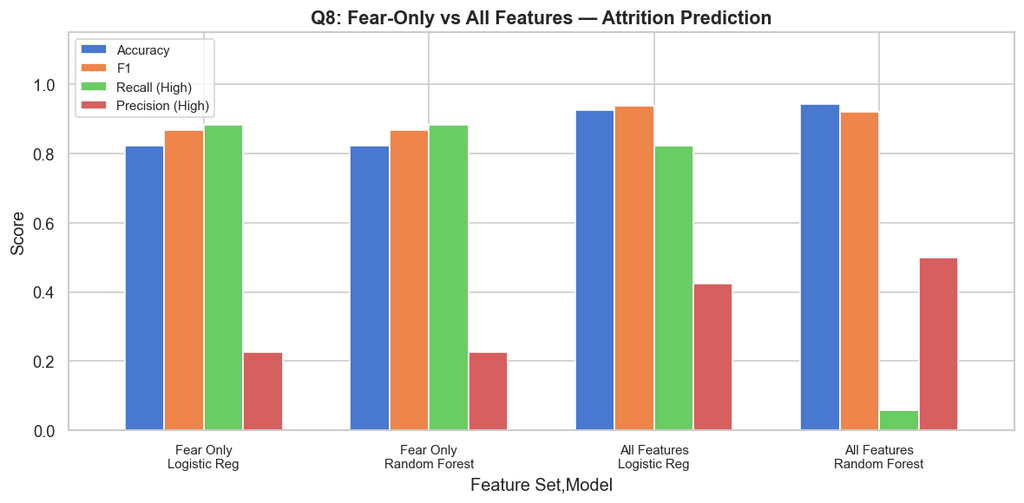

|  | Feature Set | Model | Accuracy | F1 | Recall (High) | Precision (High) |
| --- | --- | --- | --- | --- | --- | --- |
| 0 | Fear Only | Logistic Reg | 0.8227 | 0.8666 | 0.8824 | 0.2273 |
| 1 | Fear Only | Random Forest | 0.8227 | 0.8666 | 0.8824 | 0.2273 |
| 2 | All Features | Logistic Reg | 0.9264 | 0.9371 | 0.8235 | 0.4242 |
| 3 | All Features | Random Forest | 0.9431 | 0.9214 | 0.0588 | 0.5000 |

```python
# Q8: Model with fear_of_ai_replacement ONLY vs ALL features
y_q8 = df['attrition_binary']

# Fear-only features
fear_cols = [c for c in feature_encoded.columns if 'fear_of_ai_replacement' in c]
X_q8_fear = feature_encoded[fear_cols]

# All features (excluding attrition_risk)
X_q8_all = feature_encoded.drop(columns=[c for c in feature_encoded.columns if c.startswith('attrition_risk')])

print(f"Fear-only features: {X_q8_fear.columns.tolist()}")
print(f"All features: {X_q8_all.shape[1]} columns")

# Compare: Fear-only model vs Full model
results_q8 = []
for label, X_set in [('Fear Only', X_q8_fear), ('All Features', X_q8_all)]:
    X_tr, X_te, y_tr, y_te = train_test_split(X_set, y_q8, test_size=0.2, random_state=42, stratify=y_q8)
    sc = StandardScaler()
    X_tr_s = sc.fit_transform(X_tr)
    X_te_s = sc.transform(X_te)

    for name, model in [
        ('Logistic Reg', LogisticRegression(max_iter=1000, class_weight='balanced', random_state=42)),
        ('Random Forest', RandomForestClassifier(100, class_weight='balanced', random_state=42)),
    ]:
        model.fit(X_tr_s, y_tr)
        preds = model.predict(X_te_s)
        results_q8.append({
            'Feature Set': label,
            'Model': name,
            'Accuracy': accuracy_score(y_te, preds),
            'F1': f1_score(y_te, preds, average='weighted'),
            'Recall (High)': recall_score(y_te, preds, pos_label=1, zero_division=0),
            'Precision (High)': precision_score(y_te, preds, pos_label=1, zero_division=0),
        })

q8_df = pd.DataFrame(results_q8).round(4)

# Plot comparison
fig, ax = plt.subplots(figsize=(10, 5))
q8_pivot = q8_df.set_index(['Feature Set', 'Model'])[['Accuracy', 'F1', 'Recall (High)', 'Precision (High)']]
q8_pivot.plot(kind='bar', ax=ax, width=0.7)
ax.set_title('Q8: Fear-Only vs All Features — Attrition Prediction', fontweight='bold', fontsize=13)
ax.set_ylabel('Score')
ax.set_xticklabels([f"{fs}\n{m}" for fs, m in q8_pivot.index], rotation=0, fontsize=9)
ax.legend(fontsize=9)
ax.set_ylim(0, 1.15)
plt.tight_layout()
plt.show()

q8_df
```

```
======================================================================
Q8: PER-CLASS METRICS — Attrition from Fear of AI (Both Classes)
======================================================================

────────────────────────────── Fear Only + Logistic Reg ──────────────────────────────
              precision    recall  f1-score   support

        Stay       0.99      0.82      0.90       282
       Leave       0.23      0.88      0.36        17

    accuracy                           0.82       299
   macro avg       0.61      0.85      0.63       299
weighted avg       0.95      0.82      0.87       299


────────────────────────────── Fear Only + Random Forest ──────────────────────────────
              precision    recall  f1-score   support

        Stay       0.99      0.82      0.90       282
       Leave       0.23      0.88      0.36        17

    accuracy                           0.82       299
   macro avg       0.61      0.85      0.63       299
weighted avg       0.95      0.82      0.87       299


────────────────────────────── All Features + Logistic Reg ──────────────────────────────
              precision    recall  f1-score   support

        Stay       0.99      0.93      0.96       282
       Leave       0.42      0.82      0.56        17

    accuracy                           0.93       299
   macro avg       0.71      0.88      0.76       299
weighted avg       0.96      0.93      0.94       299


────────────────────────────── All Features + Random Forest ──────────────────────────────
              precision    recall  f1-score   support

        Stay       0.95      1.00      0.97       282
       Leave       0.50      0.06      0.11        17

    accuracy                           0.94       299
   macro avg       0.72      0.53      0.54       299
weighted avg       0.92      0.94      0.92       299
```

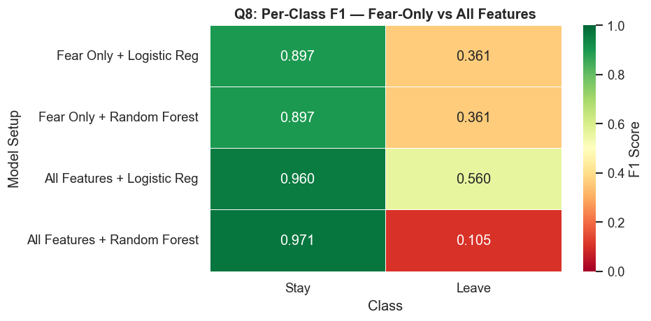

```
🎯 KEY INSIGHT: Compare 'Leave' F1 across setups.
   Fear-Only catches more leavers (high recall) but with low precision (many false alarms).
   All Features improves precision but may miss some leavers.
```

```python
# --- Q8: Per-Class Breakdown — Fear-Only vs All Features ---
class_labels_q8 = ['Stay', 'Leave']
y_q8 = df['attrition_binary']

print("=" * 70)
print("Q8: PER-CLASS METRICS — Attrition from Fear of AI (Both Classes)")
print("=" * 70)

f1_data_q8 = {}
for label, X_set in [('Fear Only', X_q8_fear), ('All Features', X_q8_all)]:
    X_tr, X_te, y_tr, y_te = train_test_split(X_set, y_q8, test_size=0.2, random_state=42, stratify=y_q8)
    sc = StandardScaler()
    X_tr_s = sc.fit_transform(X_tr)
    X_te_s = sc.transform(X_te)

    for name, model in [
        ('Logistic Reg', LogisticRegression(max_iter=1000, class_weight='balanced', random_state=42)),
        ('Random Forest', RandomForestClassifier(100, class_weight='balanced', random_state=42)),
    ]:
        model.fit(X_tr_s, y_tr)
        preds = model.predict(X_te_s)
        combo = f"{label} + {name}"

        print(f"\n{'─'*30} {combo} {'─'*30}")
        print(classification_report(y_te, preds, target_names=class_labels_q8, zero_division=0))
        rpt = classification_report(y_te, preds, target_names=class_labels_q8,
                                     output_dict=True, zero_division=0)
        f1_data_q8[combo] = {cls: rpt[cls]['f1-score'] for cls in class_labels_q8}

# Per-class F1 heatmap
f1_df_q8 = pd.DataFrame(f1_data_q8).T
fig, ax = plt.subplots(figsize=(8, 4))
sns.heatmap(f1_df_q8, annot=True, fmt='.3f', cmap='RdYlGn', vmin=0, vmax=1,
            ax=ax, linewidths=0.5, cbar_kws={'label': 'F1 Score'})
ax.set_title('Q8: Per-Class F1 — Fear-Only vs All Features', fontweight='bold')
ax.set_ylabel('Model Setup')
ax.set_xlabel('Class')
plt.tight_layout()
plt.show()

print("\n🎯 KEY INSIGHT: Compare 'Leave' F1 across setups.")
print("   Fear-Only catches more leavers (high recall) but with low precision (many false alarms).")
print("   All Features improves precision but may miss some leavers.")
```

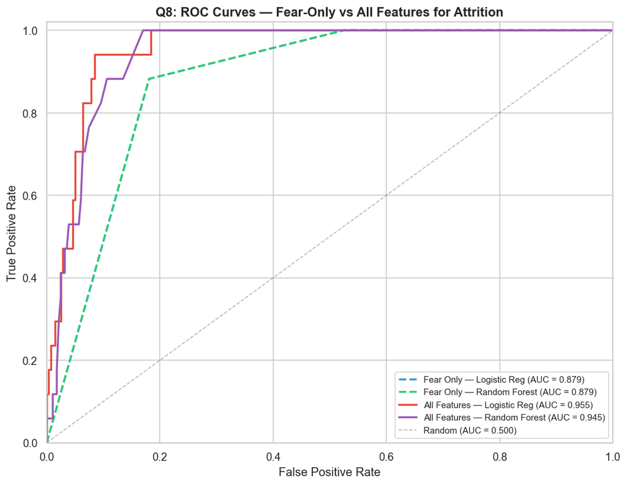

```
Q8 ROC-AUC Summary:
  Fear Only — Logistic Reg: AUC = 0.8787
  Fear Only — Random Forest: AUC = 0.8787
  All Features — Logistic Reg: AUC = 0.9547
  All Features — Random Forest: AUC = 0.9453
```

```python
# Q8: ROC Curves — Fear-Only vs All Features (both model types)
fig, ax = plt.subplots(figsize=(9, 7))
colors_q8 = ['#3498db', '#2ecc71', '#e74c3c', '#9b59b6']
line_styles = ['--', '--', '-', '-']

q8_roc_data = []
for label, X_set in [('Fear Only', X_q8_fear), ('All Features', X_q8_all)]:
    X_tr, X_te, y_tr, y_te = train_test_split(X_set, y_q8, test_size=0.2, random_state=42, stratify=y_q8)
    sc = StandardScaler()
    X_tr_s = sc.fit_transform(X_tr)
    X_te_s = sc.transform(X_te)

    for name, model in [
        ('Logistic Reg', LogisticRegression(max_iter=1000, class_weight='balanced', random_state=42)),
        ('Random Forest', RandomForestClassifier(100, class_weight='balanced', random_state=42)),
    ]:
        model.fit(X_tr_s, y_tr)
        y_prob = model.predict_proba(X_te_s)[:, 1]
        q8_roc_data.append((f'{label} — {name}', y_te, y_prob))

for (lbl, y_te, y_prob), color, ls in zip(q8_roc_data, colors_q8, line_styles):
    fpr, tpr, _ = roc_curve(y_te, y_prob)
    auc_score = auc(fpr, tpr)
    ax.plot(fpr, tpr, color=color, linewidth=2, linestyle=ls, label=f'{lbl} (AUC = {auc_score:.3f})')

ax.plot([0, 1], [0, 1], 'k--', linewidth=1, alpha=0.3, label='Random (AUC = 0.500)')
ax.set_xlabel('False Positive Rate', fontsize=12)
ax.set_ylabel('True Positive Rate', fontsize=12)
ax.set_title('Q8: ROC Curves — Fear-Only vs All Features for Attrition',
             fontsize=13, fontweight='bold')
ax.legend(loc='lower right', fontsize=9)
ax.set_xlim([0, 1])
ax.set_ylim([0, 1.02])
plt.tight_layout()
plt.show()

# Print AUC summary
print("Q8 ROC-AUC Summary:")
for lbl, y_te, y_prob in q8_roc_data:
    print(f"  {lbl}: AUC = {roc_auc_score(y_te, y_prob):.4f}")
```

### Q8 Summary — Does Fear of AI Replacement Predict Attrition?

**Crosstab findings:**

- **High fear** → 21.8% have High attrition risk (very strong signal)
- **Low fear** → only 0.8% have High attrition risk
- **Medium fear** → only 0.2% have High attrition risk
- Fear of AI replacement is a **massive differentiator** (27× higher attrition rate for High-fear vs Low-fear)

#### Per-Class Breakdown — Fear-Only vs All Features:

| Setup | Stay F1 | Leave F1 | Leave Precision | Leave Recall | Verdict |
| --- | --- | --- | --- | --- | --- |
| Fear Only + Logistic Reg | 0.90 | 0.36 | 0.23 | **0.88** | Best recall — catches 88% of leavers |
| Fear Only + Random Forest | 0.90 | 0.36 | 0.23 | **0.88** | Identical to Logistic (same 2-feature decision) |
| **All Features + Logistic Reg** | 0.96 | **0.56** | 0.42 | 0.82 | ✅ **Best balance** — good recall + improved precision |
| All Features + Random Forest | **0.97** | 0.11 | 0.50 | **0.06** | ❌ Nearly useless for catching leavers |

#### Understanding the Metrics — Why Weighted F1 Hides the Story

> **Weighted F1** averages each class's F1 weighted by sample count. With ~94% Stay vs ~6% Leave, Stay's F1 counts **16× more** in the weighted score — a model can look great just by predicting "Stay" for everyone.  
> **Minority-class F1** (Leave F1) directly answers: "Can the model actually find employees who are about to leave?"

> **In Q8:** All Features + Random Forest has a high Stay F1 (0.97) that inflates its Weighted F1, but its Leave F1 is just 0.11 — it catches only 1 out of 17 leavers. All Features + Logistic Reg has a slightly lower Stay F1 (0.96) but a **5× higher Leave F1** (0.56) because it actually learns to detect the minority class. The fear-only models sacrifice Stay F1 (0.90) to push Leave Recall to 88%, showing that fear alone is a powerful but imprecise signal.

**🔑 Key insights from per-class analysis:**

- Fear-only models have **identical performance** for both Logistic Reg and Random Forest — with only 2 binary features, both algorithms learn the same simple rule
- All Features + Random Forest **breaks completely** on the Leave class (recall=6%, catching 1 out of 17) — same failure mode as in Q2
- All Features + Logistic Reg is the **sweet spot**: catches 82% of leavers while cutting false alarms in half vs fear-only (precision 23%→42%, Leave F1 0.36→0.56)
- The jump from fear-only to all-features in Logistic Reg shows other features add meaningful signal on top of fear

**Answer to Q8:** Yes — **fear of AI replacement is the single strongest predictor of attrition**. Fear-only models catch **88% of leavers** but with high false alarm rate (23% precision). Adding all features with Logistic Reg provides the best balance (82% recall, 42% precision, Leave F1=0.56). **Avoid Random Forest for this task** — its tendency to default to the majority class makes it nearly blind to attrition cases despite impressive accuracy numbers.

## Classification Summary — Why Per-Class Metrics Changed the Story

**The single biggest lesson from this analysis:** Weighted-aggregate metrics (accuracy, weighted F1) systematically favoured Gradient Boosting and Random Forest, but **per-class breakdowns revealed these models often ignore the minority class** — the very class we're trying to detect.

[output not shown]

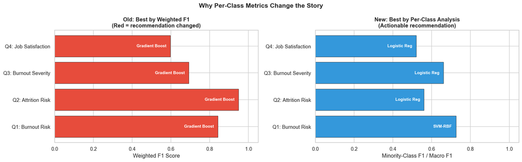

```python
# === Classification Summary — Weighted Aggregate vs Per-Class Recommended ===

# --- Weighted aggregate best (old approach) ---
clf_summaries_weighted = []
for qname, res_df in [('Q1: Burnout Risk', q1_results), ('Q2: Attrition Risk', q2_results),
                        ('Q3: Burnout Severity', q3_results), ('Q4: Job Satisfaction', q4_results)]:
    best = res_df['CV F1 Mean'].idxmax()
    row = res_df.loc[best]
    clf_summaries_weighted.append({
        'Question': qname,
        'Best (Weighted F1)': best,
        'Test Accuracy': row['Accuracy'],
        'Weighted F1': row['F1 (weighted)'],
    })

# --- Per-class recommended (new approach) ---
perclass_recs = {
    'Q1: Burnout Risk': {
        'model': 'SVM-RBF', 'reason': 'Best minority F1=0.725, Recall=84.6%',
        'minority_f1': 0.725, 'minority_recall': 0.846
    },
    'Q2: Attrition Risk': {
        'model': 'Logistic Reg', 'reason': 'Leave F1=0.560, Recall=82.4% (RF catches only 6%!)',
        'minority_f1': 0.560, 'minority_recall': 0.824
    },
    'Q3: Burnout Severity': {
        'model': 'Logistic Reg', 'reason': 'Most balanced Macro F1=0.660, smallest gap',
        'minority_f1': 0.660, 'minority_recall': None
    },
    'Q4: Job Satisfaction': {
        'model': 'Logistic Reg', 'reason': 'Only model that predicts Low class (F1=0.43; RF=0.000)',
        'minority_f1': 0.520, 'minority_recall': None
    },
}

for s in clf_summaries_weighted:
    q = s['Question']
    rec = perclass_recs[q]
    s['Recommended (Per-Class)'] = rec['model']
    s['Reason'] = rec['reason']
    s['Changed?'] = '⚠️ YES' if s['Best (Weighted F1)'] != rec['model'] else '✅ Same'

summary_df = pd.DataFrame(clf_summaries_weighted).set_index('Question').round(4)

print("=" * 90)
print("CLASSIFICATION RESULTS — Weighted Aggregate vs Per-Class Recommendation")
print("=" * 90)
print(summary_df[['Best (Weighted F1)', 'Recommended (Per-Class)', 'Changed?', 'Reason']].to_string())

print("\n\n⚠️  MODEL RECOMMENDATION CHANGED IN 3 OUT OF 4 QUESTIONS!")
print("   Weighted metrics consistently favoured Gradient Boost / Random Forest,")
print("   but per-class analysis revealed they neglect the minority class we actually care about.")
print("   Logistic Regression and SVM-RBF are better choices for actionable predictions.")

# --- Visual: Side-by-side comparison chart ---
fig, axes = plt.subplots(1, 2, figsize=(16, 5))

# Left: Weighted F1 (old — misleading)
questions = [s['Question'] for s in clf_summaries_weighted]
# Manually set the original weighted-best model metrics
weighted_best_names = [s['Best (Weighted F1)'] for s in clf_summaries_weighted]
weighted_f1s = [summary_df.loc[q, 'Weighted F1'] for q in questions]

# Right: Per-class recommended — minority F1 or macro F1
rec_names = [perclass_recs[q]['model'] for q in questions]
rec_f1s = [perclass_recs[q]['minority_f1'] for q in questions]

ax = axes[0]
colors_w = ['#e74c3c' if s['Changed?'] == '⚠️ YES' else '#2ecc71' for s in clf_summaries_weighted]
bars = ax.barh(questions, weighted_f1s, color=colors_w, edgecolor='black', linewidth=0.5)
for bar, name in zip(bars, weighted_best_names):
    ax.text(bar.get_width() - 0.02, bar.get_y() + bar.get_height()/2,
            name, ha='right', va='center', fontsize=9, fontweight='bold', color='white')
ax.set_xlim(0, 1.05)
ax.set_xlabel('Weighted F1 Score')
ax.set_title('Old: Best by Weighted F1\n(Red = recommendation changed)', fontweight='bold')

ax = axes[1]
bars = ax.barh(questions, rec_f1s, color='#3498db', edgecolor='black', linewidth=0.5)
for bar, name in zip(bars, rec_names):
    ax.text(bar.get_width() - 0.02, bar.get_y() + bar.get_height()/2,
            name, ha='right', va='center', fontsize=9, fontweight='bold', color='white')
ax.set_xlim(0, 1.05)
ax.set_xlabel('Minority-Class F1 / Macro F1')
ax.set_title('New: Best by Per-Class Analysis\n(Actionable recommendation)', fontweight='bold')

plt.suptitle('Why Per-Class Metrics Change the Story', fontsize=14, fontweight='bold')
plt.tight_layout()
plt.show()
```